# 스포츠과학원 재직자교육 - R을 활용한 데이터 분석

Author

서울시립대학교 빅데이터 혁신융합대학 사업단

Published

January 21, 2026

## 패키지 로드 및 데이터 불러오기

### 패키지 불러오기 (`library()`)

앞서 `install.packages()`를 통해 패키지를 설치한 것은 스마트폰에 앱을 ’다운로드’한 것과 같다. 앱을 사용하려면 아이콘을 눌러서 실행해야 하듯이, R에서도 설치된 패키지를 사용하려면 이 패키지를 사용 할 것이라 선언해 주는 과정이 필요하다.

이때 사용하는 함수가 `library()`이다,

- **설치:** 컴퓨터에 한 번만 하면 됨. (인터넷 필요)
- **실행:** RStudio를 켤 때마다, 해당 기능을 쓰기 위해 매번 실행해야 함. (오프라인 가능)

```r
# 데이터를 다루는 'dplyr' 패키지 실행
library(dplyr)
# 엑셀 파일을 읽어오는 'readxl' 패키지 실행
library(readxl)
# 그래프를 그리는 'ggplot2' 패키지 실행
library(ggplot2)
```

현재 내 RStudio에 어떤 패키지들이 로드되어(활성화되어) 있는지 확인하려면 `search()` 함수를 사용한다.

```r
search()
```

[output not shown]

**주의사항**

R의 패키지들은 전 세계 사용자들이 자발적으로 만든 것이므로 아주 드물게 오류가 있을 수 있다는 점을 항상 염두에 두어야 한다.

### 외부 데이터 불러오기

R에서 데이터를 직접 타이핑해서 입력하는 경우는 거의 없다. 대부분 엑셀이나 회사 시스템에서 내려받은 파일을 R로 가져와서 분석하게 된다. 가장 많이 사용하는 두 가지 파일 형식인 `.csv`와 `.xlsx(엑셀)` 파일을 불러오는 방법을 알아보자.

1. **CSV 파일 불러오기**

   가장 흔하게 접하게 될 파일 형식은 `.csv`이이다. CSV는 **Comma Separated Values**의 약자로, 겉보기엔 엑셀 파일 같지만 실제로는 데이터들이 쉼표(,)로 구분된 단순한 텍스트 파일이이다. 용량이 가볍고 호환성이 좋아 데이터 분석에서 가장 선호하는 형식이다.

   R에서 CSV 파일을 불러올 때는 `read.csv()` 함수를 사용한다.

**파일 경로 지정 팁**

- (X) `"C:\Users\Data\file.csv"`
- (O) `"C:/Users/Data/file.csv`

```r
# 파일 경로를 큰따옴표("") 안에 넣어주세요.
read.csv("C:/Users/Data/my_data.csv")
```

2. **한글이 깨져서 보일 때 (인코딩 문제)**

   한국인 사용자에게 가장 골치 아픈 문제이다. 파일을 불러왔는데 `ꍪꍫ` 같은 외계어가 나온다면 **인코딩(Encoding)** 방식이 맞지 않아서이다. 이럴 때는 `fileEncoding` 옵션을 추가한다.
   - **CP949**: 보통 윈도우 환경에서 만든 파일일 때
   - **UTF-8**: 맥(Mac)이나 웹, 최신 시스템에서 만든 파일일 때

```r
# 윈도우 엑셀로 저장한 CSV라면 보통 CP949입니다.
read.csv("파일경로/파일명.csv", fileEncoding = "CP949")

# 그래도 깨진다면 UTF-8을 시도해보세요.
read.csv("파일경로/파일명.csv", fileEncoding = "UTF-8")
```

3. **첫 번째 줄이 제목일 때 (Header)**

   데이터 파일의 첫 번째 줄(행)이 변수명(칼럼명)인 경우가 많다. `read.csv`는 기본적으로 첫 줄을 제목으로 인식하지만(`header = TRUE`), 만약 첫 줄부터 바로 데이터가 시작된다면 `header = FALSE` 옵션을 주어야 한다.
4. **엑셀 파일(.xlsx) 불러오기**

   순수 엑셀 파일(`.xls`, `.xlsx`)을 불러올 때는 R의 기본 기능으로는 안 되고, `readxl`이라는 패키지의 힘을 빌려야 한다. (위에서 `library(readxl)`을 했는지 꼭 확인!)
   - `.xls` 파일 (구버전 엑셀): `read_xls()` 함수 사용
   - `.xlsx` 파일 (신버전 엑셀): `read_xlsx()` 함수 사용

   엑셀 파일은 여러 개의 시트(Sheet) 로 구성된 경우가 많다. 특정 시트의 데이터만 가져오고 싶다면 `sheet` 옵션에 번호나 시트 이름을 적어주면 된다.

```r
# 엑셀 파일 불러오기
read_xlsx("C:/Users/Data/sales_data.xlsx")

# 두 번째 시트에 있는 데이터만 가져오고 싶을 때
read_xlsx("C:/Users/Data/sales_data.xlsx", sheet = 2)
```

# 1. R의 기초

## 1.1 연산

### 1.1.1 기초 연산

`R`은 사칙연산(덧셈, 뺄셈, 곱셈, 나눗셈)에 대한 기본적인 기능을 제공한다.  
특히 곱셈 기호는 문자 `x`가 아니라 연산자 `*`를 사용한다는 점에 주의하자.

```r
1 + 2
```

```r
1 - 2
```

```r
2 * 2
```

```r
2 / 2
```

### 1.1.2 비교 연산

`R`에서는 부등호와 등호를 이용한 **비교 연산**이 가능하다.  
비교 연산자는 조건문, 필터링, 논리 판단 등에 자주 사용된다.

비교 연산을 수행하면 결과로 `TRUE` 또는 `FALSE`가 출력된다.

```r
3 > 2      # TRUE
5 == 10    # FALSE
4 != 4     # FALSE
7 <= 9     # TRUE
```

## 1.2 변수

### 1.2.1 변수 할당

`R`에서 변수를 생성(할당)하는 방법은 여러 가지가 있지만, 그 중 `<-` 또는 `=` 연산자가 가장 자주 사용된다.  
`x`라는 변수에 2를, `y`라는 변수에 5를 저장해보자:

```r
x <- 2
y = 5
```

### 1.2.2 변수 이름 규칙

`R`에서 변수 이름을 정할 때는 다음과 같은 규칙이 적용된다:

1. 변수 이름은 반드시 **영문자 또는 마침표(`.`), 밑줄(`_`)로 시작**해야 한다. 숫자로 시작할 수는 없다.
2. 변수 이름에는 **영문자, 숫자, 마침표(`.`), 밑줄(`_`)**만 사용할 수 있다.
3. **공백(띄어쓰기)**이나 특수문자(예: `@`, `!`, `-` 등)는 사용할 수 없다.
4. 대소문자를 구분한다. (`score`와 `Score`는 다른 변수로 인식됨)
5. `R`의 **예약어**(예: `if`, `for`, `TRUE`, `function` 등)는 변수 이름으로 사용할 수 없다.

### 1.2.3 변수 제거

변수를 제거하려면 `rm()` 함수를 사용한다.  
삭제하고자 하는 변수명을 `rm()` 함수 안에 넣어주면 해당 변수가 메모리에서 제거된다.

- `ls()`: 현재 작업 환경에 저장되어 있는 변수들의 이름을 나열해준다.
- `rm()`: 변수를 삭제한다. 삭제하려는 변수의 이름을 `rm()` 함수 안에 넣어 실행하면 된다. 예: `rm(x)`는 변수 `x`를 삭제한다.

```r
x <- 10
ls()
rm(x)   # 변수 x 제거
```

## 1.3 데이터타입

`R`에서 사용되는 데이터 타입은 매우 다양하지만, 그중에서도 네 가지 주요 데이터 타입이 자주 사용된다:  
`numeric`, `character`, `logical`, `Date/POSIXct`

이번 교육에서는 이 중에서 `numeric`, `character`, `logical` 세 가지 타입을 중심으로 다루도록 하겠다.

## 1.3.1 `numeric` 자료

`R`은 대다수의 자료가 숫자형태로 존재하게 된다. `numeric` 자료는 정수, 실수를 다루며 어떤 변수가 `numeric`인지 확인하는 함수는 `is.numeric()`을 통해 이루어진다.

`R`에서는 대부분의 데이터가 숫자 형태로 표현되며, 이러한 데이터를 `numeric` 타입이라고 한다.  
`numeric` 자료형은 **정수(integer)**와 **실수(double)**를 모두 포함한다.

어떤 변수가 `numeric` 타입인지 확인하려면 `is.numeric()` 함수를 사용한다.

```r
x <- 3.14
is.numeric(x)   # TRUE
```

정수를 생성하고 싶은 경우, 숫자 뒤에 `L`을 붙이면 해당 변수를 **정수(integer)**로 생성할 수 있다.

```r
x <- 10L
is.integer(x)   # TRUE
is.numeric(x)   # TRUE (정수도 numeric의 하위 개념)
```

어떤 변수의 데이터타입을 알고 싶은 경우 `class()` 함수를 통하면 알 수 있다.

```r
x <- 3.14
class(x)    # "numeric"
```

## 1.3.2 `character` 자료

`R`에서 `character`(문자형)는 `numeric`만큼이나 자주 사용되는 데이터 타입이다.  
문자형 데이터는 텍스트, 범주형 값, 이름 등의 정보를 저장할 때 사용된다.

`R`에서는 문자형 데이터를 다루는 방식이 두 가지로 구분된다:  
하나는 일반적인 문자열 자료인 `character` 타입이고, 다른 하나는 범주형 데이터를 위한 `factor` 타입이다.

- `character`: 단순한 문자열 데이터 (예: 이름, 도시명 등)
- `factor`: 고정된 수준(level)을 갖는 범주형 데이터 (예: 성별, 지역구분 등)

```r
name <- "Alice"
class(name)       # "character"

gender <- factor("female", levels = c("male", "female"))
class(gender)     # "factor"
```

## 1.3.3 `logical` 자료

`R`에서 `logical`(논리형)은 참(`TRUE`) 또는 거짓(`FALSE`)의 값을 표현하는 데이터 타입이다. 조건문, 필터링, 비교 연산의 결과 등에서 매우 자주 사용된다.

논리형 데이터는 다음과 같이 직접 생성할 수 있다:

```r
a <- TRUE
b <- FALSE

class(a)   # "logical"
```

또한, 비교 연산 결과는 항상 `logical` 값을 반환한다:

```r
x <- 5
x > 3      # TRUE
x == 10    # FALSE
```

`logical` 값은 숫자 연산과도 호환되며, `TRUE`는 1, `FALSE`는 0으로 간주되어 계산에 활용될 수 있다:

```r
TRUE + TRUE    # 2
TRUE * 5 # 5
```

### 1.4 벡터 (Vector)

`R`에서 가장 기본적인 데이터 구조는 **벡터**이다.  
벡터는 **동일한 데이터 타입을 갖는 값들의 모음**으로, 숫자형, 문자형, 논리형 등 다양한 타입의 벡터를 생성할 수 있다.

벡터를 만드는 가장 일반적인 방법은 `c()` 함수를 사용하는 것이다.  
`c()`는 “combine”의 약자로 여러 값을 하나의 벡터로 결합해준다.

```r
# 숫자형 벡터
num_vec <- c(1, 2, 3, 4, 5)

# 문자형 벡터
char_vec <- c("apple", "banana", "cherry")

# 논리형 벡터
log_vec <- c(TRUE, FALSE, TRUE, TRUE)
```

벡터는 **동일한 데이터 타입**만 저장할 수 있는 자료구조이다.  
서로 다른 타입의 값을 함께 넣으면 `R`은 자동으로 **가장 일반적인 타입**으로 변환(coercion)하여 벡터를 생성한다.

예를 들어, 다음과 같은 벡터에는 세 가지 타입(숫자형, 문자형, 논리형)이 혼합되어 있으므로 문자형을 반환한다.

```r
v <- c(1, 2, "김", TRUE)
print(v)
# 출력: "1" "2" "김" "TRUE"
class(v)    # "character"
```

### 1.4.1 벡터 연산

`R`에서는 벡터 간의 연산이 **원소별(element-wise)**로 자동 수행된다.  
벡터 연산은 `R`의 강력한 기능 중 하나로, 복잡한 반복문 없이도 간결하게 계산을 처리할 수 있다.

```r
a <- c(1, 2, 3)
b <- c(4, 5, 6)

a + b   # 각 위치의 값끼리 더함: 1+4, 2+5, 3+6 → 5 7 9
a - b   # -3 -3 -3
a * b   # 4 10 18
a / b   # 0.25 0.4 0.5
```

벡터는 스칼라 값과도 연산이 가능하며, 각 원소에 동일한 연산이 적용된다:

```r
a <- c(1, 2, 3)
a + 10     # 11 12 13
a * 2      # 2 4 6
```

두 벡터의 길이가 다르면, 짧은 쪽 벡터의 값을 자동으로 반복하여 연산한다. 이를 **재활용 규칙(recycling rule)**이라고 한다.

```r
a <- c(1, 2, 3, 4)
b <- c(10, 100)

a + b     # 1+10, 2+100, 3+10, 4+100 → 11 102 13 104
```

### 1.4.2 벡터 인덱싱

`R`에서 벡터의 특정 요소에 접근하거나 일부 값을 선택하기 위해 **인덱싱**을 사용할 수 있다.  
`R`의 인덱스는 **1부터 시작**한다는 점에 주의해야 한다.

```r
x <- c(10, 20, 30, 40, 50)

x[1]       # 첫 번째 요소 10
x[3]       # 세 번째 요소 30
x[c(2, 4)] # 두 번째와 네 번째 요소 20 4
```

음수를 사용하면 해당 위치의 요소를 제외할 수 있다.

```r
x[-1]      # 첫 번째 요소 제외 20 30 40 50
x[-c(2, 5)]# 2번째와 5번째 제외 10 30 40
```

`TRUE`/`FALSE` 값을 이용해 원하는 요소만 선택할 수 있다.

```r
x <- c(5, 10, 15, 20)

x > 10          # FALSE FALSE TRUE TRUE
x[x > 10]       # 조건을 만족하는 값만 → 15 20
```

벡터에 `이름(names)` 을 지정하면, 이름을 통해 인덱싱할 수 있다.

```r
x <- c(a = 100, b = 200, c = 300)
x["b"]         # 200
names(x)       # "a" "b" "c"
```

### 1.4.3 범주형 벡터 (`factor` vector)

`R`에서는 **범주형(categorical)** 데이터를 표현할 때 `factor` 벡터를 사용한다.  
`factor`는 문자형 데이터처럼 보이지만, 내부적으로는 **고정된 수준(level)**을 가지는 **정수형 벡터**로 처리된다.

```r
gender <- c("male", "female", "male", "female", "female")
gender <- as.factor(gender)
gender
# 출력: [1] male   female male   female female
# Levels: female male
```

```r
as.numeric(gender)
```

### 1.4.4 벡터 관련 주요함수

`R`에서는 벡터를 다루기 위해 다양한 기본 함수들이 제공된다.  
아래는 자주 사용되는 대표적인 벡터 함수들이다.

`length()` — 벡터의 길이(요소 개수) 반환

```r
x <- c(10, 20, 30, 40)
length(x)   # 4
```

`sum()` — 모든 요소의 합계 계산

```r
sum(x)      # 100
```

`mean()` — 평균값 계산

```r
mean(x)     # 25
```

`max()` / `min()` — 최대값 / 최소값

```r
max(x)      # 40
min(x)      # 10
```

`sort()` - 정렬

```r
sort(x)           # 오름차순 10 20 30 40
sort(x, decreasing = TRUE)  # 내림차순 40 30 20 10
```

### 1.4.5 NA vs NULL

`R`에서 결측값(빠진 데이터)을 표현할 때는 주로 `NA`와 `NULL`이 사용된다.  
이 둘은 비슷해 보이지만 의미와 동작이 **완전히 다르다**.

`NA` (Not Available)

- **결측값(missing value)**을 의미
- 벡터나 데이터프레임 내에서 **값은 존재하지만 비어 있음**
- 수치 연산 또는 통계 처리 대상에 포함됨

```r
x <- c(1, 2, NA, 4)
mean(x)                # NA (결측이 포함되면 결과도 NA)
mean(x, na.rm = TRUE)  # 2.33 (결측값 무시하고 계산)
```

`NULL`

- 존재 자체가 없음
- 길이가 0이고, 연산 대상에도 포함되지 않음

```r
y <- NULL
length(y)     # 0

z <- c(1, NULL, 3)   # NULL은 무시됨 c(1, 3)
```

# 2. 데이터 프레임 I

`data.frame`은 `R`에서 가장 많이 사용되는 데이터 구조 중 하나로, **여러 개의 벡터(열)를 같은 길이로 묶어 2차원 형태의 표 형식 데이터**로 만든 것이다.

엑셀의 시트처럼 **행(row)**과 **열(column)**로 구성되어 있으며, 각 열은 서로 다른 타입(`numeric`, `character`, `logical` 등)을 가질 수 있다.

아래 그림을 보자. 데이터프레임에서 **열(column)**은 각각 하나의 **변수(variable)**를 나타내고, **행(row)**은 각 변수에 대한 하나의 **관측치(observation)**를 의미한다.

Figure 1: 데이터프레임의 구조

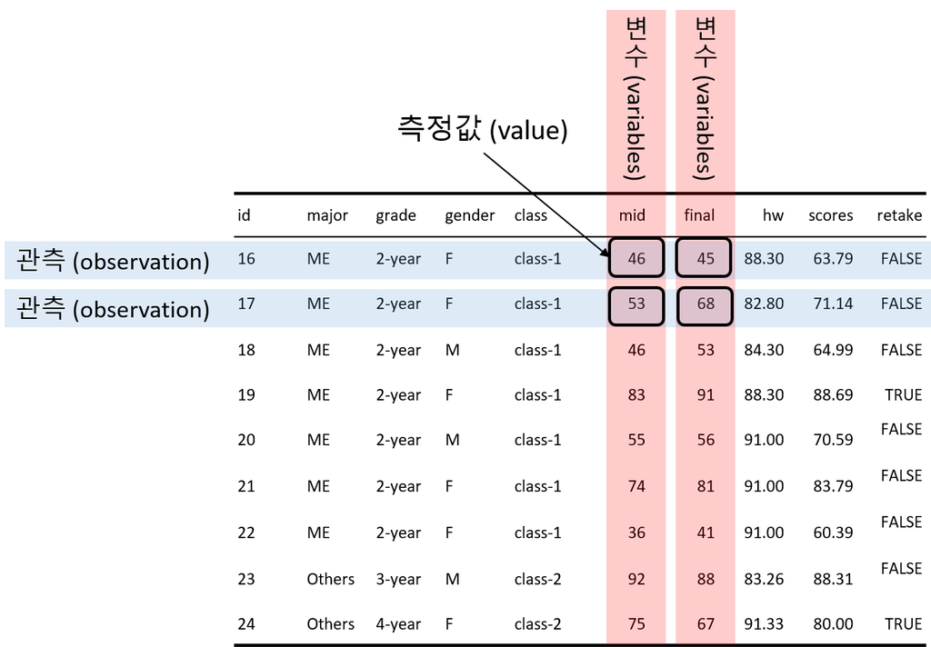

R의 문법을 익히는 가장 효과적인 방법은 실제 데이터를 직접 다뤄보는 것이다. 이번 교육 과정에서는 `ggplot2` 패키지에 내장된 `mpg` 데이터 를 활용하여 실습을 진행한다.

**`mpg` 데이터 설명**

`mpg` 데이터는 미국 환경 보호국(US EPA)에서 공개한 자료로, 1999년부터 2008년까지 출시된 자동차 234종의 연비 정보를 담고 있다. 일반적인 엑셀 표와 같이 행(Row)과 열(Column)로 구성된 데이터프레임 형태이다. 별도로 파일을 다운로드할 필요 없이 `ggplot2` 패키지만 로드하면 즉시 사용할 수 있어 연습용 데이터로 널리 사용된다.

```r
library(ggplot2)
```

`mpg` 데이터의 각 열(Column)이 의미하는 바는 다음과 같다.

| 변수명 | 설명 | 예시 |
| --- | --- | --- |
| **manufacturer** | 제조사 | audi, hyundai, jeep 등 |
| **model** | 모델명 | a4, sonata 등 |
| **displ** | 배기량 (엔진 크기) | 숫자가 클수록 배기량이 큼 (예: 1.8, 2.0) |
| **year** | 생산연도 | 1999, 2008 |
| **cyl** | 실린더 개수 (기통) | 4기통, 6기통 등 |
| **trans** | 변속기 종류 | auto(자동), manual(수동) |
| **drv** | 구동 방식 | f(전륜), r(후륜), 4(4륜) |
| **cty** | **도심 연비** (City MPG) | 도심 주행 시 연비 (단위: 마일/갤런) |
| **hwy** | **고속도로 연비** (Highway MPG) | 고속도로 주행 시 연비 (단위: 마일/갤런) |
| **fl** | 연료 종류 | p(프리미엄), r(레귤러), e(에탄올) 등 |
| **class** | 자동차 종류 | compact(소형), suv, minivan 등 |

## 2.1 데이터 프레임의 생성

`R`에서 데이터프레임을 생성하는 방법은 여러 가지가 있지만,  
그 중 가장 간단한 방법은 `data.frame()` 함수를 사용하는 것이다.

이제 세 개의 벡터 `x`, `y`, `q`를 만들어 데이터프레임으로 결합해보자:

```r
x <- 10:1
y <- -4:5
q <- c("Hockey", "Football", "Baseball", "Curling", "Rugby",
       "Lacrosse", "Basketball", "Tennis", "Cricket", "Soccer")

df <- data.frame(x, y, q)
```

데이터프레임의 각 열(column)에 이름을 붙이고 싶을 경우,  
`data.frame()` 함수에서 **이름 = 벡터** 형식으로 지정하면 된다.

예를 들어 `x`, `y`, `q` 벡터를 각각 `"First"`, `"Second"`, `"Sport"`라는 이름으로 지정하려면 다음과 같이 작성한다:

```r
df <- data.frame(Fisrt = x, Second = y, Sport = q)
```

## 2.2 데이터프레임 정보 요약하기

### 2.2.1 `nrow()`, `ncol()` 그리고 `dim()`

데이터프레임을 다루다 보면 **행과 열의 개수**를 알아야 할 일이 자주 있다.  
이럴 때 사용하는 함수가 바로 `nrow()`, `ncol()`, 그리고 `dim()` 함수이다.

- `nrow()`는 행(row)의 개수를 반환한다.
- `ncol()`은 열(column)의 개수를 반환한다.
- `dim()`은 행과 열의 개수를 **벡터 형태**로 함께 반환한다.

```r
nrow(mpg)
ncol(mpg)
dim(mpg)
```

### 2.2.2 `names()`

데이터프레임의 **열 이름(column names)**을 알고 싶을 경우, 가장 간단한 방법은 `names()` 함수를 사용하는 것이다.

이 함수는 데이터프레임의 열 이름을 **문자형 벡터 형태**로 반환한다.

```r
names(mpg)
```

### 2.2.3 `str()`

`str()` 함수는 **structure(구조)**의 줄임말로,데이터 객체의 **전체 구조를 요약해서 보여주는 함수**이다.  
특히 데이터프레임이나 리스트처럼 복잡한 구조를 빠르게 파악할 때 유용하다.

```r
str(mpg)
```

### 2.2.4 `head()` 그리고 `tail()`

데이터프레임의 전체 내용을 한눈에 보기에는 행이 너무 많을 수 있다.  
이럴 때는 `head()`와 `tail()` 함수를 사용하여 **앞부분 또는 뒷부분 일부만 미리 확인**할 수 있다.

```r
head(mpg)         # 기본값: 앞 6행 출력
head(mpg, 3)      # 앞 3행 출력

tail(mpg)         # 기본값: 뒤 6행 출력
tail(mpg, 4)      # 뒤 4행 출력
```

`View()` 함수는 데이터를 엑셀처럼 새 창으로 표시하는 함수이다.

```r
View(mpg)
```

### 2.2.5 변수선택 (`$` 연산자)

데이터 프레임은 여러 개의 변수(열)가 모여 있는 형태이다. 분석을 하다 보면 전체 데이터가 아니라, “도심 연비(`cty`)의 평균만 구하고 싶다”거나 “고속도로 연비(`hwy`)만 따로 보고 싶다”는 등 특정 변수 하나만 필요할 때가 많다.

이때 사용하는 것이 바로 달러 기호(`$`)이다. `$` 연산자는 데이터 프레임 안에 있는 특정 변수(열)에 접근하는 역할을 한다.

작성 방식은 매우 간단하다. 데이터 프레임 이름 뒤에 `$`를 붙이고, 그 뒤에 원하는 변수명을 적으면 된다.

- 형식: `데이터프레임명$변수명`
- 의미: “**데이터프레임** 안에 있는(**$**) **변수**를 꺼내라”

```r
head(mpg$cty)
```

## 2.3 데이터프레임 주요 함수

### 2.3.1 `table()` 함수

```r
table(mpg$manufacturer)
```

### 2.3.2 `colSums()`와 `colMeans()`

`colSums()`와 `colMeans()`는 각각 데이터프레임의 **각 열(column)**에 대해  
**합계(sum)**와 **평균(mean)**을 계산해주는 함수이다.

이 함수들은 **수치형(numeric)** 열에만 적용되며, **문자형 열이 포함된 경우 오류메세지가 나온다.**

```r
colSums(mpg)
colMeans(mpg)
```

### 2.3.3 `summary()`

`summary()`함수는 데이터프레임 또는 벡터의 **각 변수(열)**에 대한  
요약 통계 정보를 빠르게 확인할 수 있는 함수이다.

- 최소값 (`Min.`)
- 1사분위수 (`1st Qu.`)
- 중앙값 (`Median`)
- 평균 (`Mean`)
- 3사분위수 (`3rd Qu.`)
- 최대값 (`Max.`)

```r
summary(mpg)
```

## 2.4 데이터프레임 인덱싱

벡터와 마찬가지로, **데이터프레임도 인덱싱을 통해 원하는 값에 접근하거나 추출**할 수 있다.  
이때 자주 사용하는 연산자가 `[]`이다.

### 2.4.1 `[]` 연산자 - 행과 열 모두 인덱싱가능

`[i, j]` 형태의 대괄호 인덱싱에서 `i`는 **행 번호**, `j`는 **열 번호**를 나타낸다.  
따라서 특정 위치의 값을 추출하고 싶을 때 이 형식을 사용할 수 있다.

예를 들어, **2행 3열**에 있는 데이터에 접근하고 싶다면 다음과 같이 작성한다:

```r
mpg[2, 3]
```

**1개 이상의 열 또는 행**을 선택하고 싶을 때는 **벡터 인덱싱**을 사용할 수 있다.  
`:` 연산자나 `c()` 함수를 이용하여 원하는 범위를 지정할 수 있다.

예를 들어, **3행의 2~3열**을 선택하고 싶다면 다음과 같이 작성한다:

```r
mpg[3, 2:3]
mpg[3, c(2, 3)]
```

데이터프레임에서 열을 추출하고자 할 때는 `[ , j]` 형식을 사용하며,  
이때 `j` 자리에는 **열의 위치(숫자)** 또는 **열의 이름(문자열)**을 넣을 수 있다.

```r
mpg[, 3]
mpg[, 2:3]
mpg[, c("model", "displ")]
```

`[]` 형태의 인덱싱에서는 논리연산 결과를 이용한 조건 인덱싱이 가능하다. 이때 `TRUE`인 위치의 값만 추출되며, `FALSE`인 위치의 값은 제외된다.

```r
mpg$model == "a4"
mpg[mpg$model == "a4", ]
```

데이터프레임의 변수에 접근하고자 하는경우 행렬을 다룰 때와 마찬가지로 벡터 인덱싱을 사용하거나 데이터프레임 뒤에 `$`를 붙이고 변수 이름을 작성하는 방법도 있다.

- 인덱싱을 사용하는 경우

```r
mpg[, 1]
mpg[, "manufacturer"]
```

`$`를 사용하는 경우

```r
mpg$manufacturer
```

지금의 예제에서 둘은 같은 결과를 보여주지만 특정 상황에서는 인덱싱을 사용하거나 `$`를 사용할 수 밖에 없는 상황이 존재하니 두 방법 모두 익혀두자.

`str()` 함수는 데이터프레임에 있는 변수들의 객체 유형과 관측치 개수를 파악하는 유용한 함수이다.

```r
str(mpg)
```

### 2.4.2 복합조건 인덱싱 (and, or)

두 가지 이상의 조건을 연결해야 할 때는 논리 연산자를 사용한다.

- **AND 연산자 (`&`)**: 두 조건이 **모두** 참이어야 할 때
- **OR 연산자 (`|`)**: 두 조건 중 **하나라도** 참이면 될 때 (`Shift` + `\` 키)
1. **AND 조건 예시 (`&`):** 제조사가 “audi”이면서(**그리고**), 연비(cty)가 20 이상인 데이터를 추출하고 싶을 때 사용한다.

   ```r
   # manufacturer가 "audi"이고, cty가 20 이상인 행 추출
   mpg[mpg$manufacturer == "audi" & mpg$cty >= 20, ]
   ```

2. **OR 조건 예시 (`|`)** 차종(class)이 “compact”이거나(**또는**), “midsize”인 데이터를 추출하고 싶을 때 사용한다.

[output not shown]

3. **행 조건과 열 조건의 결합**

   마지막으로, 복합 조건으로 행을 걸러냄과 동시에 보고 싶은 열만 선택하는 방법이다. `[행 조건, 열 선택]` 형식을 그대로 따르면 된다.

   ```r
   # audi 차량 중(행 조건)에서 model과 year 변수만(열 선택) 확인
   mpg[mpg$manufacturer == "audi", c("model", "year")]
   ```

### 2.5 예제

데이터 분석의 핵심은 “내가 원하는 데이터만 뽑아내서(Indexing), 그 특성을 요약(Statistics)하는 것”이다. 다음 5가지 예제를 통해 이 과정을 연습해 보자.

#### 예제 1: 특정 제조사 자동차의 연비 평균 구하기

“**Audi**에서 만든 자동차들의 **도심 연비(cty)** 평균은 얼마일까?”

1. 행 조건: `manufacturer`가 “audi”인 데이터
2. 열 선택: `cty` (도심 연비)
3. 함수: `mean()` (평균)

```r
# 1단계: audi 차량만 추출하여 audi_cars 변수에 저장
audi_cars <- mpg[mpg$manufacturer == "audi", ]

# 2단계: 추출된 데이터에서 cty 변수의 평균 계산
mean(audi_cars$cty)

# (심화) 한 줄로 작성하기
mean(mpg[mpg$manufacturer == "audi", "cty"])
```

#### 예제 2: 두 차종 간의 고속도로 연비 비교하기

“**SUV** 차량과 **Compact(경차/소형)** 차량 중 누가 고속도로 연비가 더 좋을까?”

1. 행 조건: `class`가 “suv”인 것 vs “compact”인 것
2. 열 선택: `hwy` (고속도로 연비)
3. 함수: `mean()` (평균)으로 비교

```r
# SUV 차량의 고속도로 연비 평균
suv_hwy <- mpg[mpg$class == "suv", "hwy"]
mean(suv_hwy)

# Compact 차량의 고속도로 연비 평균
compact_hwy <- mpg[mpg$class == "compact", "hwy"]
mean(compact_hwy)
```

결과를 비교해보면 일반적으로 Compact 차량의 연비가 훨씬 높게 나옵니다.

#### 예제 3: 복합 조건(AND) 데이터의 요약 통계 보기

“2000년 이후에 생산된 차량 중, **배기량(displ)이 4.0 이상**인 대형차들의 연비 분포는 어떠한가?”

1. 행 조건: `year >= 2000` **그리고(&)** `displ >= 4.0`
2. 열 선택: `cty` (도심 연비)
3. 함수: `summary()` (최소, 최대, 평균, 중위수 등 전체 요약)

```r
# 조건에 맞는 데이터를 big_engine_cars에 저장
big_engine_cars <- mpg[mpg$year >= 2000 & mpg$displ >= 4.0, ]

# 해당 차량들의 도심 연비 요약 통계 확인
summary(big_engine_cars$cty)
```

#### 예제 4: 복합 조건(OR) 데이터의 개수 세기

“제조사가 **Chevrolet**이거나 **Ford**인 미국 자동차는 이 데이터에 총 몇 대가 있을까?”

1. 행 조건: `manufacturer == "chevrolet"` **또는(|)** `manufacturer == "ford"`
2. 함수: `nrow()` (행의 개수) 또는 `table()` (빈도표)

```r
# 쉐보레 또는 포드 자동차 추출
us_cars <- mpg[mpg$manufacturer == "chevrolet" | mpg$manufacturer == "ford", ]

# 전체 개수(행의 수) 확인
nrow(us_cars)

# (심화) 제조사별로 몇 대씩인지 나누어 보기
table(us_cars$manufacturer)
```

#### 예제 5: 특정 조건 데이터의 최댓값 찾기

“**4기통(cyl == 4)** 차량 중에서 가장 높은 고속도로 연비(hwy)는 얼마인가?”

1. 행 조건: `cyl`이 4인 데이터
2. 열 선택: `hwy` (고속도로 연비)
3. 함수: `max()` (최댓값)

```r
# 4기통 차량 데이터만 먼저 추출
cyl4_cars <- mpg[mpg$cyl == 4, ]

# 그 중에서 고속도로 연비 최댓값 확인
max(cyl4_cars$hwy)

# (참고) 최솟값은 min() 함수 사용
min(cyl4_cars$hwy)
```

## 2.5 데이터프레임 합치기

## 2.5.1 `join()`

데이터 분석을 하다 보면 **두 개 이상의 데이터프레임을 특정 기준(key)**을 기준으로  
결합해야 하는 경우가 많다. 이때 사용하는 함수가 바로 `join()`이다.

`join()` 함수는 기본적으로 **공통된 열(기준 변수)**을 기준으로 두 데이터프레임을 병합하며,  
`dplyr` 패키지에서 제공하는 다양한 종류의 `join` 함수들이 자주 사용된다.

| 함수 | 설명 |
| --- | --- |
| `inner_join()` | 양쪽 모두에 존재하는 행만 결합 (교집합) |
| `left_join()` | 왼쪽 데이터프레임 기준, 오른쪽 값이 없으면 `NA` |
| `right_join()` | 오른쪽 데이터프레임 기준, 왼쪽 값이 없으면 `NA` |
| `full_join()` | 양쪽 모든 행을 결합 (합집합), 없는 값은 `NA`로 채움 |

Figure 2: Inner Join

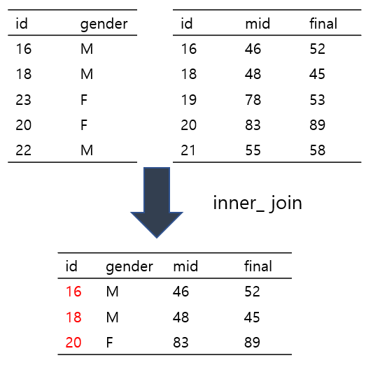

Figure 3: Left Join

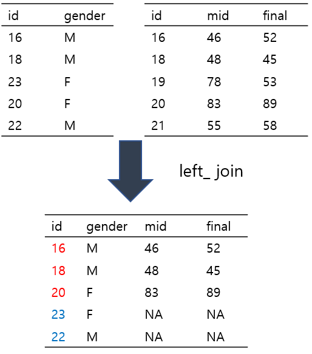

Figure 4: Right Join

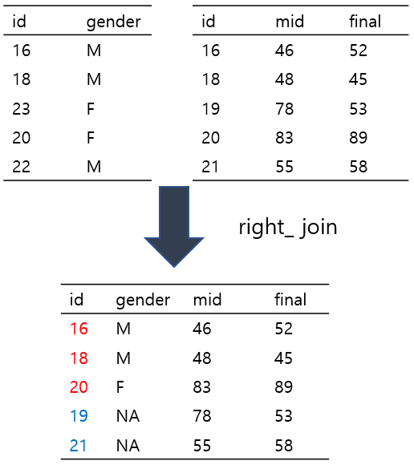

Figure 5: Full Join

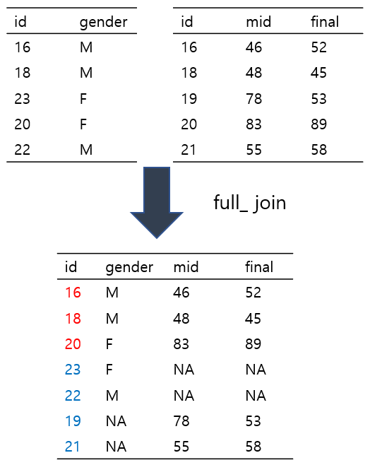

```r
students <- data.frame(id = c(1, 2, 3), name = c("Kim", "Lee", "Park"))
scores <- data.frame(id = c(1, 3, 4), score = c(90, 85, 70))

left_join(students, scores, by = "id")
```

`iris` 데이터셋은 `R`에서 기본으로 제공되는 **대표적인 내장 데이터셋** 중 하나로,  
**붓꽃(iris) 3종류에 대한 꽃받침과 꽃잎의 길이/너비** 정보를 담고 있다.

총 **150개의 관측값(행)**과 **5개의 변수(열)**로 구성되어 있으며, 각 변수는 다음과 같은 정보를 담고 있다:

| 변수 이름 | 설명 |
| --- | --- |
| `Sepal.Length` | 꽃받침 길이 (cm) |
| `Sepal.Width` | 꽃받침 너비 (cm) |
| `Petal.Length` | 꽃잎 길이 (cm) |
| `Petal.Width` | 꽃잎 너비 (cm) |
| `Species` | 붓꽃의 품종 (`setosa`, `versicolor`, `virginica`) |

앞서 배운 `head()`, `dim()`, `str()` 등의 함수를 이용하면  
`iris` 데이터셋의 **기본 구조와 내용을 빠르게 파악**할 수 있다.

```r
head(iris)    # 상위 6행 출력 (미리 보기)
dim(iris)     # 행과 열의 개수 확인 150 5
str(iris)     # 변수의 타입과 예시 값 확인
```

### 2.5.1 `rbind()`와 `cbind()` — 행/열 결합 함수

`R`에서는 데이터프레임이나 행렬을 **행(row) 또는 열(column)** 방향으로  
결합할 때 `rbind()`와 `cbind()` 함수를 사용한다.

이를 `iris` 데이터셋을 통해 직접 살펴보자.

#### `rbind()` — 행 결합 (아래로 붙이기)

`rbind()`는 두 개 이상의 데이터프레임을 **행 방향으로 결합**한다.  
즉, **관측값(행)**을 추가하는 경우에 사용한다.

```r
new_row <- data.frame(
  Sepal.Length = 5.1,
  Sepal.Width = 3.5,
  Petal.Length = 1.4,
  Petal.Width = 0.2,
  Species = "setosa"
)

iris_extended <- rbind(iris, new_row)
nrow(iris_extended)   # 151
tail(iris_extended)
```

- 열 이름과 순서가 기존 데이터프레임과 동일해야 결합 가능

#### `cbind()` — 열 결합 (옆으로 붙이기)

`cbind()`는 두 개 이상의 벡터 또는 데이터프레임을 열 방향으로 결합한다. 즉, **새로운 변수(열)**을 추가할 때 사용한다.

```r
New_Var <- sample(1:100, 150)   # 임의의 수치형 벡터

iris_with_new <- cbind(iris, New_Var)
head(iris_with_new)
```

## 2.6 데이터프레임 서브세팅

데이터 분석에서 **서브세팅(subsetting)**은 원하는 조건에 맞는 일부 데이터만 추출하는 중요한 작업이다. 이번에는 `iris` 데이터셋을 중심으로 다양한 서브세팅 방법들을 살펴보자.

### 2.6.1 조건에 맞는 행 추출

`Species`가 `"setosa"`인 행만 추출하고 싶다면:

```r
iris[iris$Species == "setosa", ]
```

비슷하게, `Sepal.Length`가 5보다 큰 행만 추출하려면:

```r
iris[iris$Sepal.Length > 5, ]
```

### 2.6.2 `subset()` 함수 사용하기

`subset()` 함수는 조건에 맞는 행 추출을 보다 간결하게 표현할 수 있도록 도와준다.

기본형식: `subset(x, subset, select)`

- `x`: 데이터프레임
- `subset`: 행 필터 조건
- `select`: 선택할 열 이름

```r
subset(iris, Species == "setosa")
subset(iris, Sepal.Length > 5)
```

다음과 같이 복수 조건을 사용할 수 있다. `|` 기호는 `R`에서 `or` 조건을, `&` 기호는 `and` 조건을 의미한다.

```r
# Species가 setosa 또는 virginica인 경우
subset(iris, Species == "setosa" | Species == "virginica")

# Species가 setosa이면서 Sepal.Length가 5보다 큰 경우
subset(iris, Species == "setosa" & Sepal.Length > 5)
```

```r
iris[iris$Species == "setosa" | iris$Species == "virginica", "Sepal.Length"]
```

# 3. `dplyr` 패키지

`dplyr` 패키지는 데이터프레임을 쉽고 직관적으로 다룰 수 있도록 도와주는 R의 핵심 패키지로, 열 선택, 행 필터링, 정렬, 요약, 그룹화 등 다양한 데이터 처리 작업을 간편하게 수행할 수 있다.

Figure 6: Dplyr

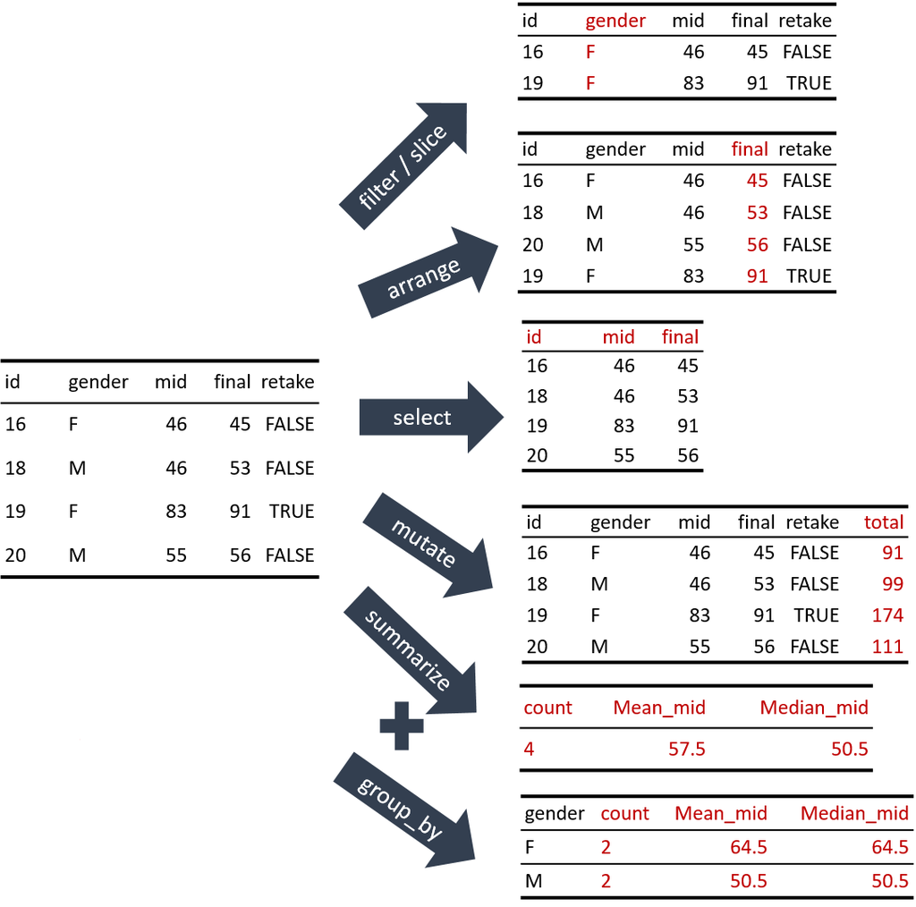

다음은 `dplyr`에서 자주 사용되는 주요 함수들이다.

| 함수 | 설명 |
| --- | --- |
| `filter()` | 조건에 맞는 행만 추출 |
| `select()` | 특정 열만 선택 |
| `arrange()` | 지정한 열을 기준으로 행 정렬 |
| `mutate()` | 새로운 열 추가 또는 기존 열 변형 |
| `summarise()` | 요약 통계 계산 (예: 평균, 합계 등) |
| `group_by()` | 그룹 단위 연산을 위해 그룹화 |
| `slice()` | 행 번호를 기준으로 행 추출 |

이번 교육에서는 `ggplot2` 패키지에 포함된 `diamonds` 데이터를 사용한다. `diamonds` 데이터는 약 54,000개의 다이아몬드에 대한 물리적 특성과 가격 정보를 포함한 데이터셋으로, `ggplot2` 패키지에 내장되어 있어 데이터 시각화 연습에 자주 사용된다.

| 변수 | 설명 | 자료형 |
| --- | --- | --- |
| `carat` | 다이아몬드 무게 (캐럿) | numeric |
| `cut` | 컷 품질 (Fair, Good, Very Good, Premium, Ideal) | ordered factor |
| `color` | 색 등급 (D~J, D가 가장 우수) | ordered factor |
| `clarity` | 투명도 등급 (I1~IF, IF가 가장 우수) | ordered factor |
| `depth` | 전체 깊이 비율 = z / mean(x, y) | numeric |
| `table` | 테이블 비율 = x축 기준 윗면 폭 비율 | numeric |
| `price` | 가격 (USD) | integer |
| `x` | 길이 (mm) | numeric |
| `y` | 너비 (mm) | numeric |
| `z` | 깊이 (mm) | numeric |

## 3.1 파이프 연산자

`dplyr`에서 자주 사용되는 파이프 연산자 (`%>%`)는 여러 연산을 연결한 문법으로 표현 할 수 있게 해주는 핵심 도구이다.

`%>%`는 앞에서 수행한 결과를 다음 함수의 첫 번째 인자로 전달하는 연산자로 복잡한 중첩 함수 호출 없이 가독성 좋고 직관적인 코드를 작성하기 위해 사용된다.

기본 사용 형태

data %>% function1() %>% function2() %>% function3()

이는 아래와 동일한 의미이다.

function3(function2(function1(data)))

```r
x <- 1:10

sum(x)
x %>%
  sum()
```

`%>%`는 `ctrl` + `shift` + `M` 단축키로 쉽게 불러올 수 있다.

## 3.2 `select()`

`select()` 함수는 데이터프레임에서 원하는 열(column)만 선택할 수 있도록 해주는 함수이다,

### 주요 사용 예시

`diamonds` 데이터를 이용하여 `carat`과 `price` 열을 선택해보자.

```r
select(diamonds, carat, price)
```

이번에는 파이프 연산자 `%>%`를 이용해 같은 작업을 수행해보자.

```r
diamonds %>%
  select(carat, price)
```

`c()` 함수를 이용해서 열을 선택할 수도 있다.

```r
diamonds %>%
  select(c(carat, price))
```

열의 위치를 인덱스하여 `select()` 함수를 이용할 수도 있다.

```r
diamonds %>%
  select(1, 7)
```

`c`로 시작하는 열만 선택하고자 할 때는 `starts_with()` 함수를 사용한다. 이 경우 `carat`, `cut`, `color`, `clarity` 열이 선택된다.

```r
diamonds %>%
  select(starts_with("c"))
```

`contains()` 함수는 열 이름에 특정 문자열이 포함된 모든 열을 선택할 때 사용한다. 예를 들어 `"l"`이 포함된 열을 선택하면 `color`, `clarity`, `table`이 선택된다.

```r
diamonds %>%
  select(contains("l"))
```

`-`는 특정 열을 제외할 때 사용하는 연산자이다. 예를 들어 `-c(carat, price)`를 사용하면 `carat`과 `price`를 제외한 나머지 열이 선택된다.

```r
diamonds %>%
  select(-carat, -price)
```

## 3.3 `filter()`

`filter()` 함수는 조건에 맞는 행(row)만 추출할 때 사용하는 함수이다.  
즉, 데이터프레임에서 원하는 조건을 만족하는 행만 선택하고 나머지는 제거된다.

#### 자주 사용하는 논리 연산자:

- `==` : 같다
- `!=` : 같지 않다
- `>` : 초과
- `<` : 미만
- `>=` : 이상
- `<=` : 이하
- `&` : 그리고 (AND)
- `|` : 또는 (OR)
- `!` : 부정 (NOT)

### 주요 사용 예시

`diamonds` 데이터에서 `cut`이 `"Ideal"`인 행만 추출하고 싶은 경우, `filter()` 함수를 다음과 같이 사용한다:

```r
diamonds %>%
  filter(cut == "Ideal")
```

`%in%`은 여러 값을 동시에 조건으로 지정하고 싶을 때 사용하는 연산자이다.  
특히 `filter()` 함수와 함께 쓰면, 여러 값 중 하나라도 일치하는 행을 선택할 수 있다.

```r
diamonds %>%
  filter(cut %in% c("Ideal", "Good"))
```

```r
diamonds %>%
  filter(price >= 1000)
```

`price`가 1000이 아닌 모든 행을 추출하고자 한다면.

```r
diamonds %>%
  filter(price != 1000)
```

```r
diamonds %>%
  filter(carat > 3 & price < 14000)
```

`carat`이 1보다 작거나 5보다 큰 행만 추출하고자 한다면

```r
diamonds %>%
  filter(carat < 1 | carat > 5)
```

## 3.4 `slice()`

`slice()` 함수는 `filter()`와는 달리 조건이 아닌 행 번호(index 또는 위치)를 기준으로 행을 선택할 때 사용하는 함수이다. 즉, 데이터프레임에서 특정 위치에 있는 행만 선택하고 나머지는 제거된다.

```r
diamonds %>%
  slice(1:5)
```

또는 `c()` 형태로도 행을 선택할 수 있다.

```r
diamonds %>%
  slice(c(1:5, 8, 15:20))
```

1행을 제외한 모든 행을 선택하고자 하는경우는 다음과 같이 한다.

```r
diamonds %>%
  slice(-1)
```

## 3.5 `mutate()`

`mutate()` 함수는 기존 열을 변형하거나 새로운 열을 추가할 때 사용하는 함수이다. 데이터프레임에 새로운 변수(column)를 생성하거나 기존 변수의 값을 바꿀 수 있는 함수이다.

예를 들어, `price/carat`의 비율을 나타내는 새로운 열을 만들어보자:

```r
diamonds %>%
  mutate(price/carat)
```

하지만 이 코드만으로는 열의 이름이 지정되지 않았고, 열이 너무 많아서 출력 시 새로 만든 열이 보이지 않을 수 있다. 이럴 때는 앞에서 배운 `select()` 함수를 사용해 관심 있는 열만 선택한 뒤, `mutate()`로 새 열을 추가하면 더 명확하게 확인할 수 있다.

```r
diamonds %>%
  select(carat, price) %>%
  mutate(price/carat)
```

이제 새로 만든 열에 `Ratio`라는 이름을 부여해보자:

```r
diamonds %>%
  select(carat, price) %>%
  mutate(Ratio = price/carat)
```

여기서 `Ratio` 값을 이용해 새로운 열을 연쇄적으로 만들 수도 있다. 예를 들어, `Ratio`에 2를 곱한 값을 `Double`이라는 이름으로 추가하면 다음과 같다:

```r
diamonds %>%
  select(carat, price) %>%
  mutate(Ratio = price/carat,
         Double = Ratio*2)
```

이처럼 `mutate()`는 다른 열을 조합하거나 가공하여 여러 새로운 변수들을 동시에 생성하는 데 매우 유용하다.

여기서 중요한 점은, `%>%`, `mutate()` 등과 같은 함수들을 사용해 데이터를 처리하더라도 원본 데이터는 실제로 변경되지 않는다는 것이다. diamonds 데이터프레임 자체는 그대로 유지되고, 변형된 결과는 일시적으로 출력될 뿐이다.

따라서, 우리가 만든 새로운 데이터를 보존하여 나중에 다시 사용하고 싶다면, 결과를 새로운 객체에 할당해주어야 한다.

```r
dia_ratio <- diamonds %>%
  select(carat, price) %>%
  mutate(Ratio = price/carat,
         Double = Ratio*2)
```

## 3.6 `summarize()`

`summarize()` 함수(또는 `summarise()`)는 데이터의 요약 통계량을 계산할 때 사용하는 함수이다. 데이터프레임 전체 또는 그룹별로 평균, 합계, 개수, 최대값, 최소값 등을 계산할 때 사용된다.

예를 들어, `diamonds` 데이터프레임에서 `price`의 평균을 계산하려면 다음과 같이 작성할 수 있다:

```r
diamonds %>%
  summarize(mean(price))
```

`summarize()` 함수에서는 평균뿐 아니라 다양한 통계량 계산도 간단히 수행할 수 있다:

```r
diamonds %>%
  summarize(AvgPrice = mean(price),
            MedianPrice = median(price),
            Avgcarat = mean(carat))
```

`summarize()`는 단독으로도 사용할 수 있지만, `group_by()`와 함께 사용하면 그룹별 통계량을 계산하는 데 특히 유용하다.

## 3.7 `group_by()`

`group_by()` 함수는 데이터를 특정 변수(또는 변수들)를 기준으로 그룹화할 때 사용하는 함수이다. 이 함수는 보통 `summarize()`와 함께 사용되어, 각 그룹별로 요약 통계량을 계산할 수 있게 한다.

예를 들어, `cut`의 종류별로 `price`의 평균을 계산하려면 다음과 같이 작성한다:

```r
diamonds %>%
  group_by(cut) %>%
  summarize(AvgPrice = mean(price))
```

이번에는 `cut`과 `color` 두 가지 기준으로 그룹화한 후, `price`의 평균과 `carat`의 합계를 함께 계산해보자:

```r
diamonds %>%
  group_by(cut, color) %>%
  summarize(AvgPrice = mean(price), SumCarat = sum(carat))
```

조금 더 나아가서, 이 중 `cut` == `"Fair"`인 그룹만 추출하고 싶다면 다음과 같이 작성한다:

```r
diamonds %>%
  group_by(cut, color) %>%
  summarize(AvgPrice = mean(price), SumCarat = sum(carat)) %>%
  filter(cut == "Fair")
```

## 3.8 `arrange()`

`arrange()` 함수는 데이터를 특정 변수(열)의 값을 기준으로 정렬할 때 사용하는 함수이다. 기본적으로 오름차순 정렬을 수행하며, desc() 함수를 함께 사용하면 내림차순 정렬도 가능하다.

```r
diamonds %>%
  group_by(cut) %>%
  summarize(AvgPrice = mean(price), SumCarat = sum(carat)) %>%
  arrange(AvgPrice)
```

```r
diamonds %>%
  group_by(cut) %>%
  summarize(AvgPrice = mean(price), SumCarat = sum(carat)) %>%
  desc(AvgPrice)
```

지금까지 배운 함수를 이용하여 다음과 같은 분석을 수행해보자.

- cut이 `"Ideal"` 또는 `"Premium"`인 다이아몬드 중에서
- `carat`, `price`, `cut`, `color` 변수만 선택하고
- `price` 대비 `carat` 비율(`carat_per_dollar`)을 계산한 후
- `cut`과 `color`별로 그룹화하여
- `carat_per_dollar`의 평균과 최대값을 구하고
- 평균이 높은 순서대로 정렬한다

# 4. ggplot2의 이해와 활용

## 왜 ggplot2를 쓰는가

R의 기본 그래픽(`plot()`)만으로도 시각화는 가능하다. 다만 그림이 조금만 복잡해져도 **수정/확장**이 불편해진다.  
예를 들어 색, 범례, 조건별 비교(facet), 통계적 요약(추세선) 등을 추가하려면 옵션을 하나씩 수동으로 만져야 한다.

반면 `ggplot2`는 **그래픽 문법(grammar of graphics)**에 기반해, 그림을 **레이어(layer)**로 쌓아 올리는 방식으로 작성한다.  
그래서 다음과 같은 장점이 생긴다.

- 코드 구조가 일정해 **재사용/수정/확장**이 쉽다.
- 변수와 시각적 속성(aes)을 연결해 **일관된 표현**이 가능하다.
- `facet`, `theme`, `scale` 같은 기능으로 **표현을 체계적으로 확장**한다.
- `dplyr`로 집계한 결과를 그대로 이어서 시각화하기 좋다.

### 기본 plot vs ggplot2

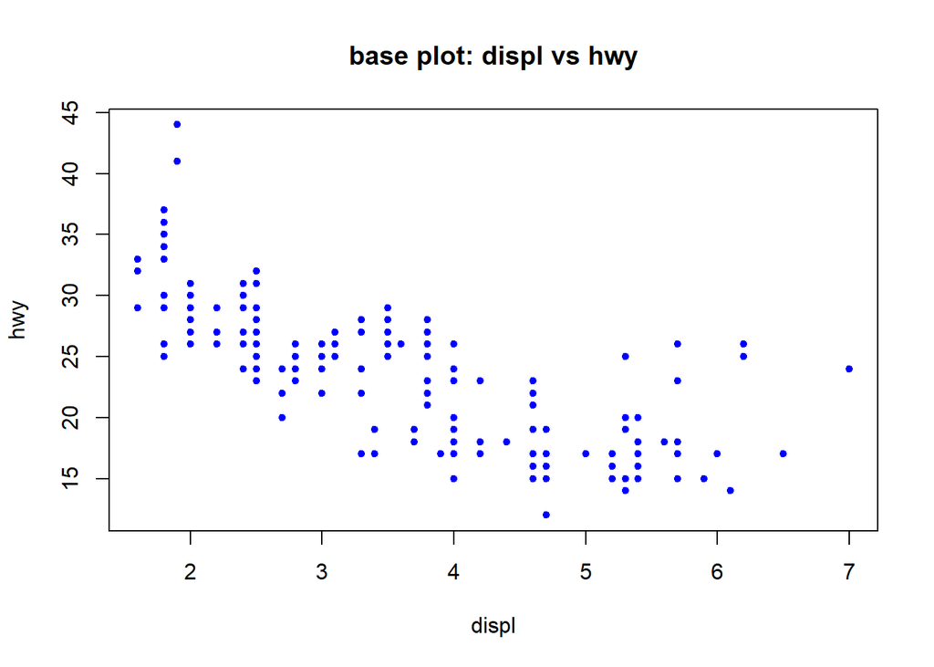

```r
# base plot
plot(mpg$displ, mpg$hwy,
     main = "base plot: displ vs hwy",
     xlab = "displ", ylab = "hwy",
     pch = 20, col = "blue")
```

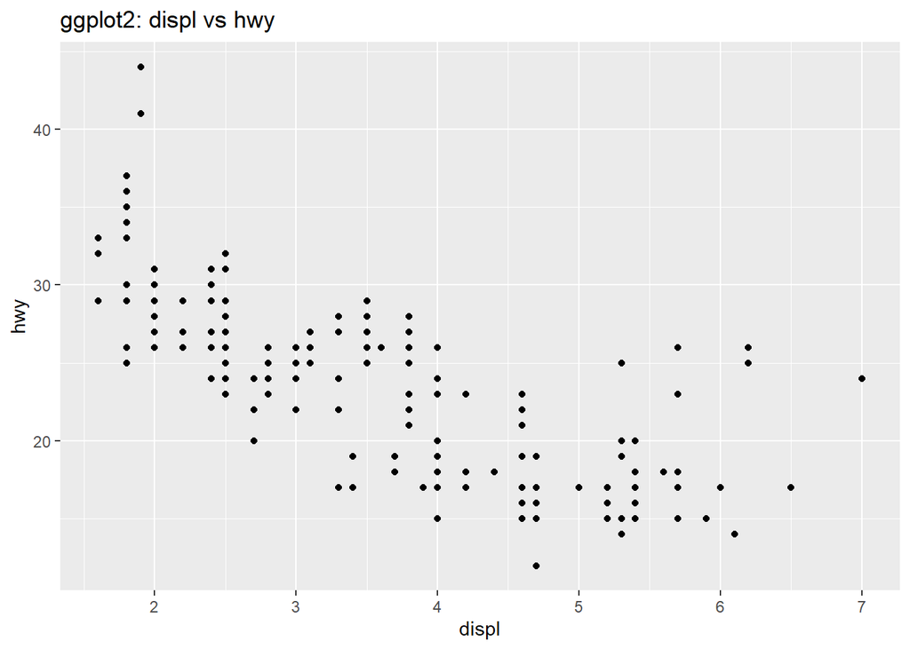

```r
# ggplot2
ggplot(mpg, aes(x = displ, y = hwy)) +
  geom_point() +
  labs(title = "ggplot2: displ vs hwy")
```

## 강의 목표

이번 실습에서는 `ggplot2`의 기본 문법을 `mpg` 데이터로 익힌다.

- `ggplot(data) + aes(...) + geom_*()` 기본 구조를 이해한다
- 산점도/막대그래프/박스플롯의 핵심 문법을 실습한다
- `facet_*`, `theme`, `scale_*`로 표현을 확장한다
- `dplyr` 집계 후 시각화까지 연결한다

## 4.0 패키지 로드와 데이터 확인

```r
library(ggplot2)
library(dplyr)
head(mpg)
```

```
# A tibble: 6 × 11
  manufacturer model displ  year   cyl trans      drv     cty   hwy fl    class
  <chr>        <chr> <dbl> <int> <int> <chr>      <chr> <int> <int> <chr> <chr>
1 audi         a4      1.8  1999     4 auto(l5)   f        18    29 p     compa…
2 audi         a4      1.8  1999     4 manual(m5) f        21    29 p     compa…
3 audi         a4      2    2008     4 manual(m6) f        20    31 p     compa…
4 audi         a4      2    2008     4 auto(av)   f        21    30 p     compa…
5 audi         a4      2.8  1999     6 auto(l5)   f        16    26 p     compa…
6 audi         a4      2.8  1999     6 manual(m5) f        18    26 p     compa…
```

```r
str(mpg)
```

```
tibble [234 × 11] (S3: tbl_df/tbl/data.frame)
 $ manufacturer: chr [1:234] "audi" "audi" "audi" "audi" ...
 $ model       : chr [1:234] "a4" "a4" "a4" "a4" ...
 $ displ       : num [1:234] 1.8 1.8 2 2 2.8 2.8 3.1 1.8 1.8 2 ...
 $ year        : int [1:234] 1999 1999 2008 2008 1999 1999 2008 1999 1999 2008 ...
 $ cyl         : int [1:234] 4 4 4 4 6 6 6 4 4 4 ...
 $ trans       : chr [1:234] "auto(l5)" "manual(m5)" "manual(m6)" "auto(av)" ...
 $ drv         : chr [1:234] "f" "f" "f" "f" ...
 $ cty         : int [1:234] 18 21 20 21 16 18 18 18 16 20 ...
 $ hwy         : int [1:234] 29 29 31 30 26 26 27 26 25 28 ...
 $ fl          : chr [1:234] "p" "p" "p" "p" ...
 $ class       : chr [1:234] "compact" "compact" "compact" "compact" ...
```

`mpg` 데이터는 자동차 연비 관련 데이터다.

- `displ`: 엔진 배기량
- `hwy`: 고속도로 연비
- `cty`: 도심 연비
- `class`: 차종
- `drv`: 구동방식

## 4.1 ggplot2의 기본 구조

`ggplot2`는 보통 아래 형태로 작성한다.

- `ggplot(data = ...)` : 사용할 데이터
- `aes(...)` : 매핑(미적 요소: x, y, color, size 등)
- `geom_*()` : 기하 객체(점/선/막대/상자그림 등)

### 4.1.1 가장 기본: 산점도

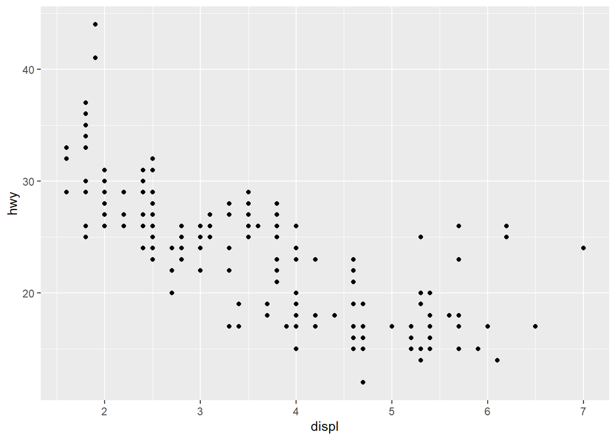

```r
ggplot(mpg, aes(x = displ, y = hwy)) +
  geom_point()
```

## 4.2. 미적요소(aes) 확장: 색/투명도

### 4.2.1 범주형 변수를 색으로

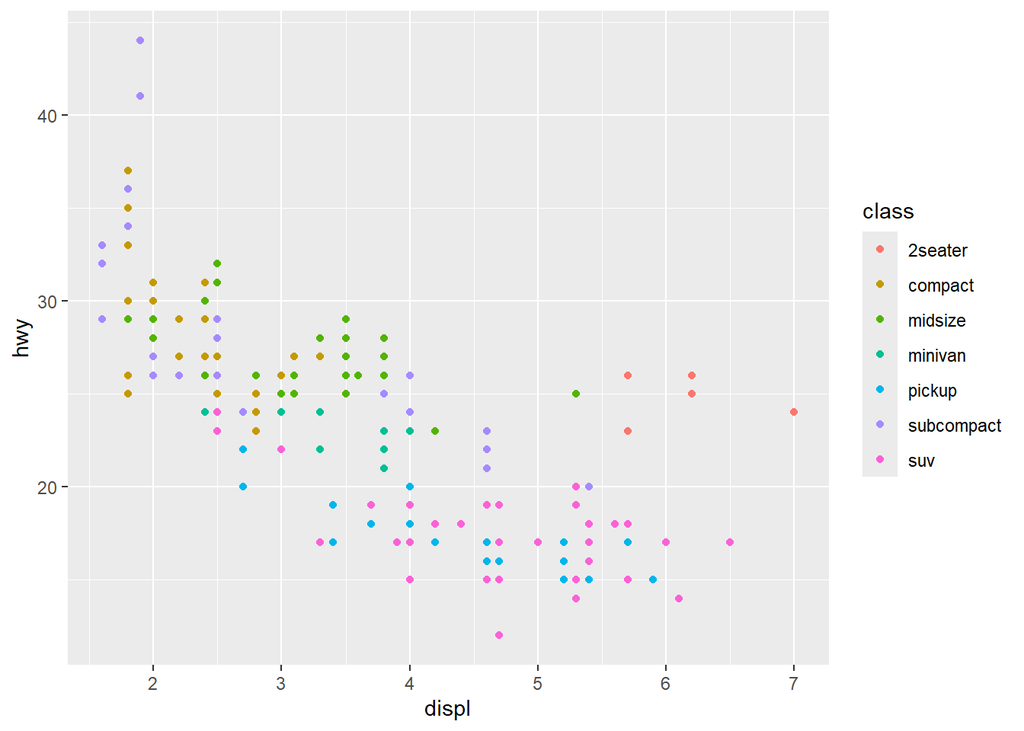

```r
ggplot(mpg, aes(x = displ, y = hwy, color = class)) +
  geom_point()
```

### 4.2.2 점 겹침 완화: 투명도(alpha)

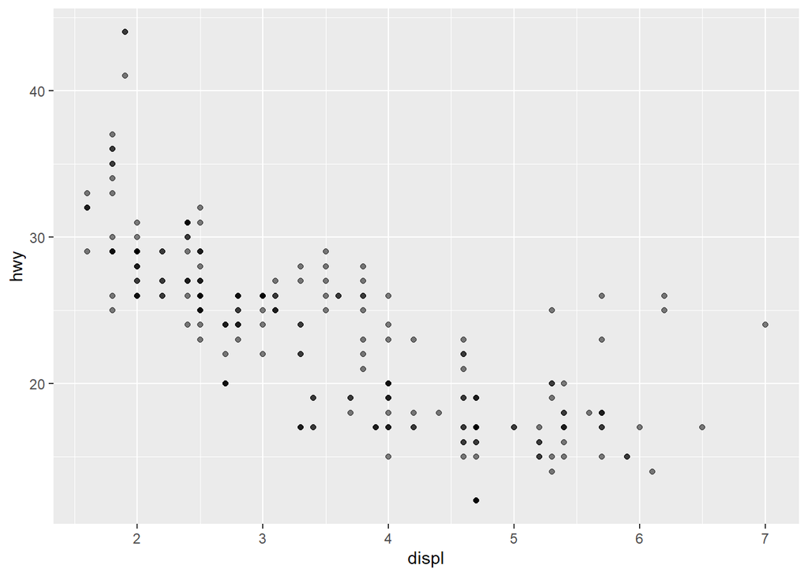

```r
ggplot(mpg, aes(x = displ, y = hwy)) +
  geom_point(alpha = 0.5)
```

> `alpha`는 0~1 사이 값이며, 값이 작을수록 더 투명해진다.

## 4.3. 레이어 추가: 추세선(geom_smooth)

### 4.3.1 전체 추세선(비선형 스무딩)

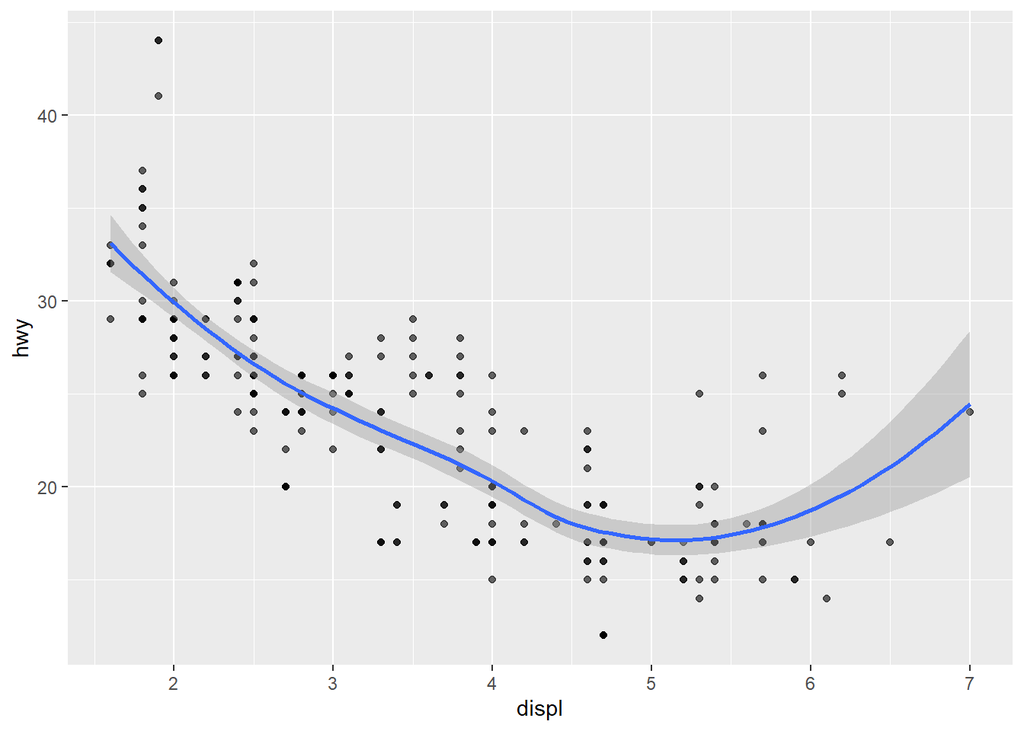

```r
ggplot(mpg, aes(x = displ, y = hwy)) +
  geom_point(alpha = 0.6) +
  geom_smooth(se = TRUE)
```

### 4.3.2 선형회귀 추세선(method = “lm”)

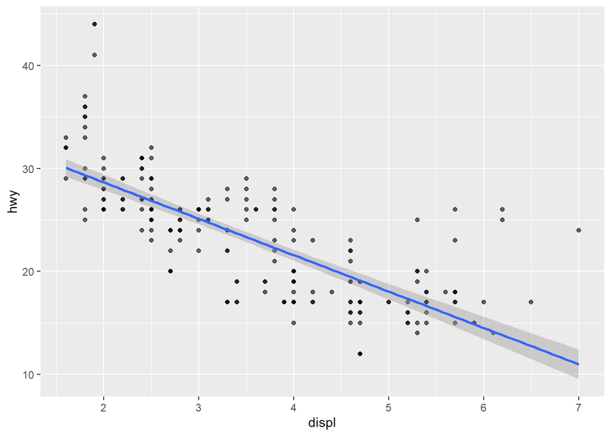

```r
ggplot(mpg, aes(x = displ, y = hwy)) +
  geom_point(alpha = 0.6) +
  geom_smooth(method = "lm", se = TRUE)
```

## 4.4. facet으로 그룹 비교

### 4.4.1 차종별로 나누어 보기

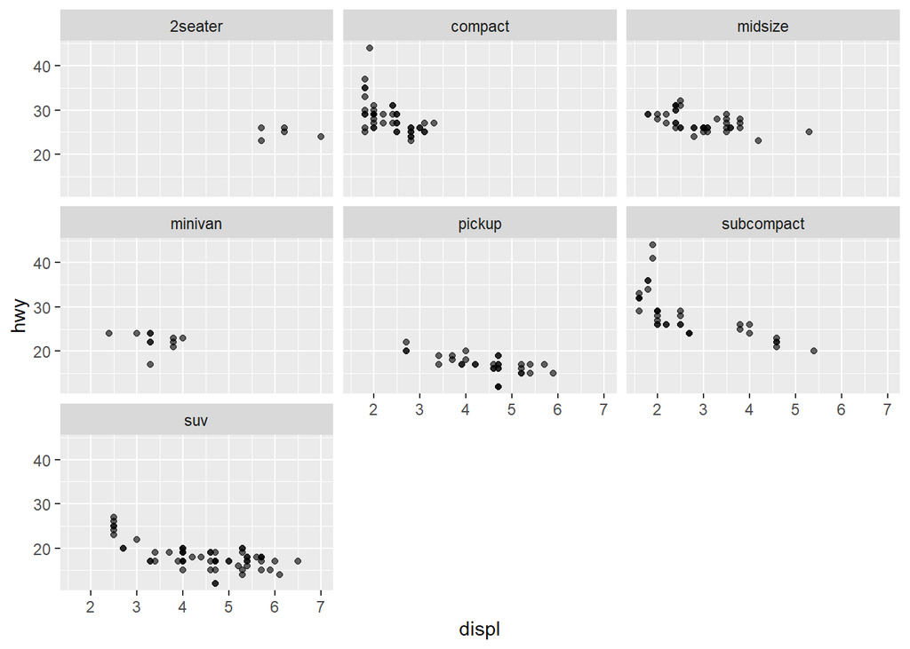

```r
ggplot(mpg, aes(x = displ, y = hwy)) +
  geom_point(alpha = 0.6) +
  facet_wrap(~ class)
```

### 4.4.2 구동방식별로 나누어 보기

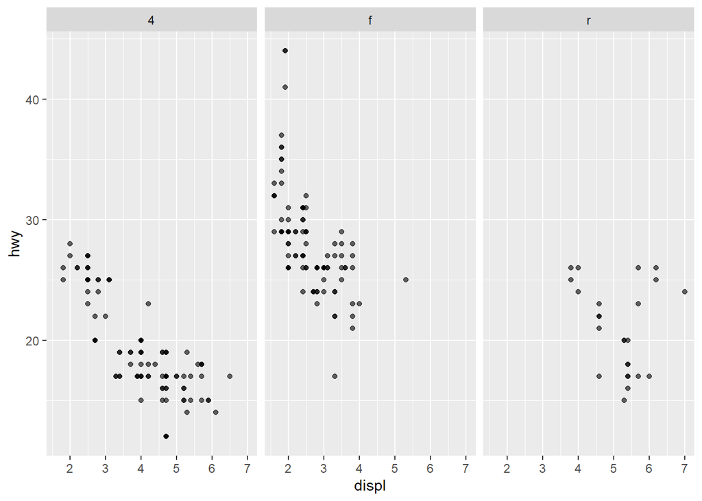

```r
ggplot(mpg, aes(x = displ, y = hwy)) +
  geom_point(alpha = 0.6) +
  facet_wrap(~ drv)
```

## 4.5. 범주형 그래프: 막대그래프 / 박스플롯

### 4.5.1 막대그래프(빈도)

`geom_bar()`는 기본적으로 **개수(count)**를 센다.

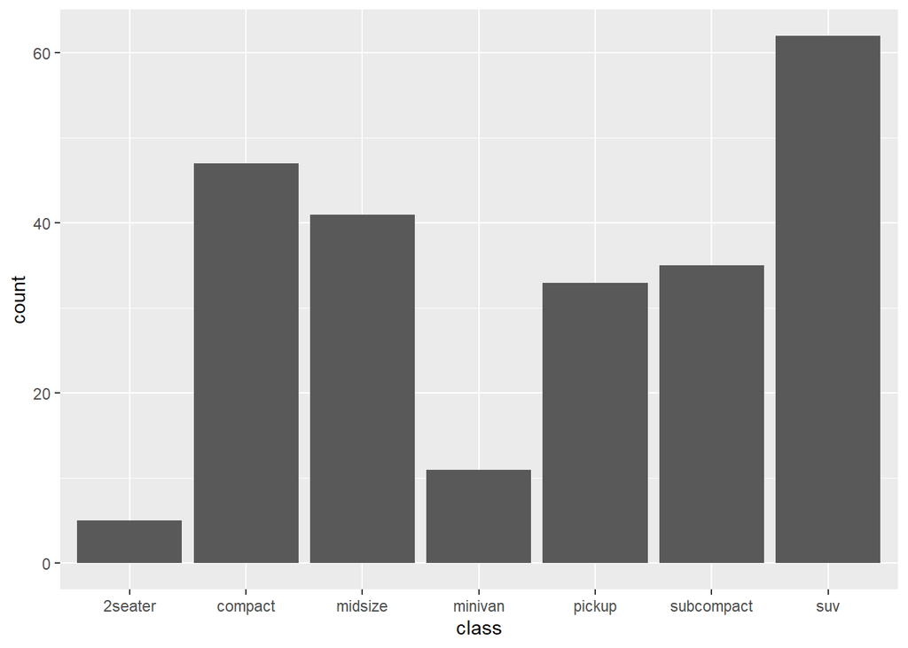

```r
ggplot(mpg, aes(x = class)) +
  geom_bar()
```

레이블이 겹치면 회전해서 가독성을 높인다.

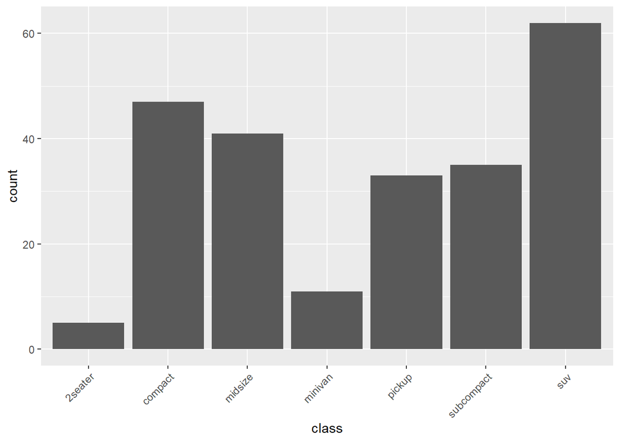

```r
ggplot(mpg, aes(x = class)) +
  geom_bar() +
  theme(axis.text.x = element_text(angle = 45, hjust = 1))
```

### 4.5.2 박스플롯: 차종별 고속도로 연비 분포

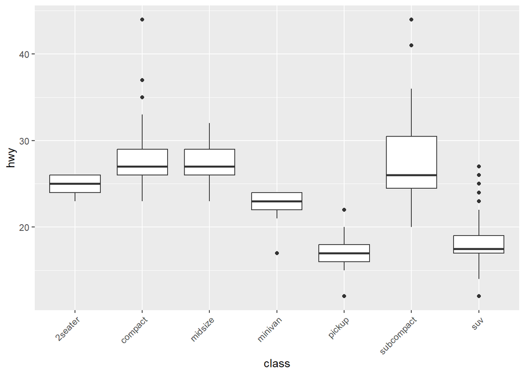

```r
ggplot(mpg, aes(x = class, y = hwy)) +
  geom_boxplot() +
  theme(axis.text.x = element_text(angle = 45, hjust = 1))
```

점도 같이 찍으면 분포가 더 직관적으로 보인다.

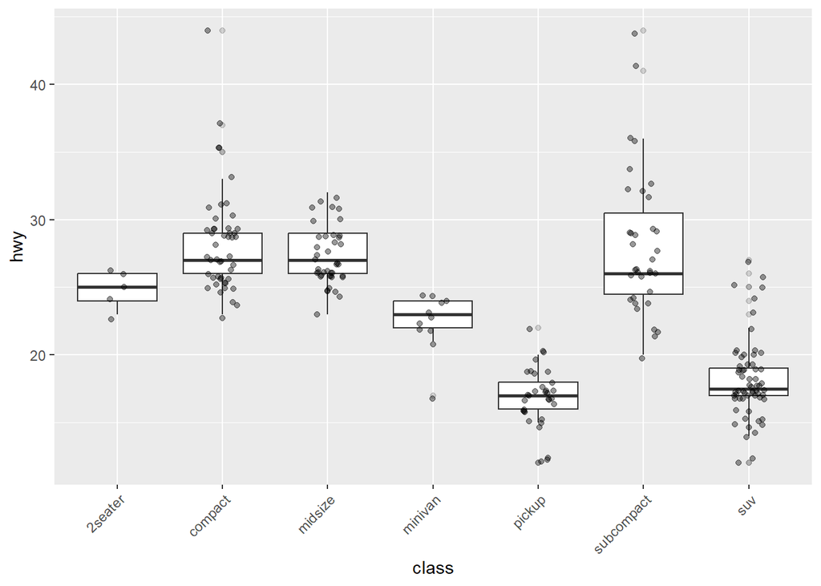

```r
ggplot(mpg, aes(x = class, y = hwy)) +
  geom_boxplot(outlier.alpha = 0.2) +
  geom_jitter(width = 0.15, alpha = 0.4) +
  theme(axis.text.x = element_text(angle = 45, hjust = 1))
```

## 4.6. 집계 후 시각화: dplyr + ggplot2

### 4.6.1 차종별 평균 hwy 계산

```r
mpg_sum <- mpg %>%
  group_by(class) %>%
  summarise(
    mean_hwy = mean(hwy),
    n = n(),
    .groups = "drop"
  )

mpg_sum
```

```
# A tibble: 7 × 3
  class      mean_hwy     n
  <chr>         <dbl> <int>
1 2seater        24.8     5
2 compact        28.3    47
3 midsize        27.3    41
4 minivan        22.4    11
5 pickup         16.9    33
6 subcompact     28.1    35
7 suv            18.1    62
```

### 4.6.2 평균 연비 막대그래프(geom_col)

`geom_col()`은 y값을 **그대로 사용**한다(집계된 데이터에 적합하다).

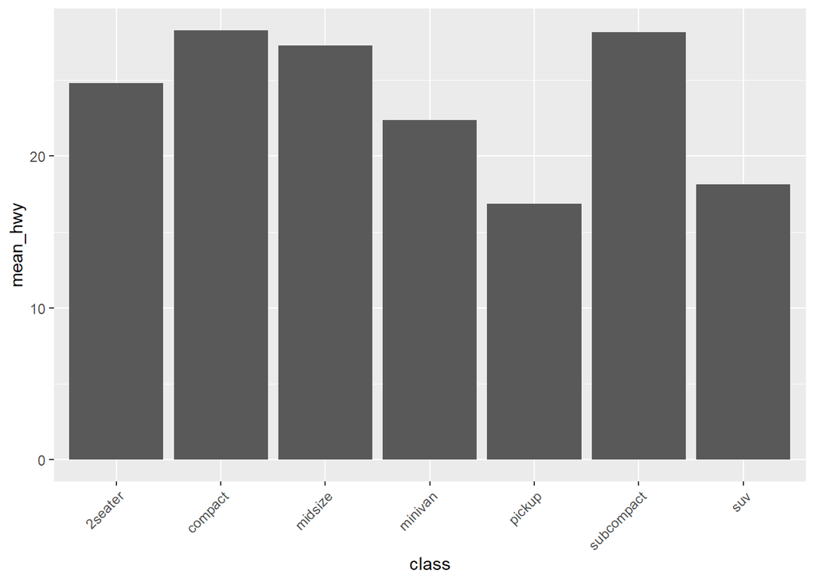

```r
ggplot(mpg_sum, aes(x = class, y = mean_hwy)) +
  geom_col() +
  theme(axis.text.x = element_text(angle = 45, hjust = 1))
```

### 4.6.3 값 기준 정렬(reorder) + 가독성(축 뒤집기)

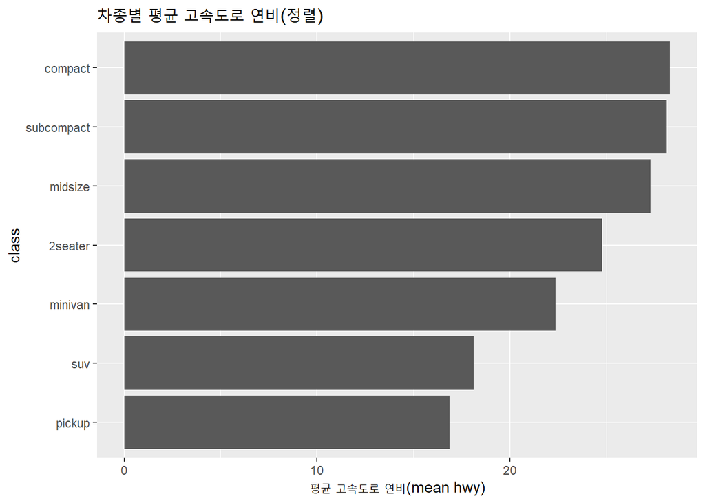

```r
ggplot(mpg_sum, aes(x = reorder(class, mean_hwy), y = mean_hwy)) +
  geom_col() +
  coord_flip() +
  labs(
    x = "class",
    y = "평균 고속도로 연비(mean hwy)",
    title = "차종별 평균 고속도로 연비(정렬)"
  )
```

## 4.7. 라벨/제목/범례 설정: labs

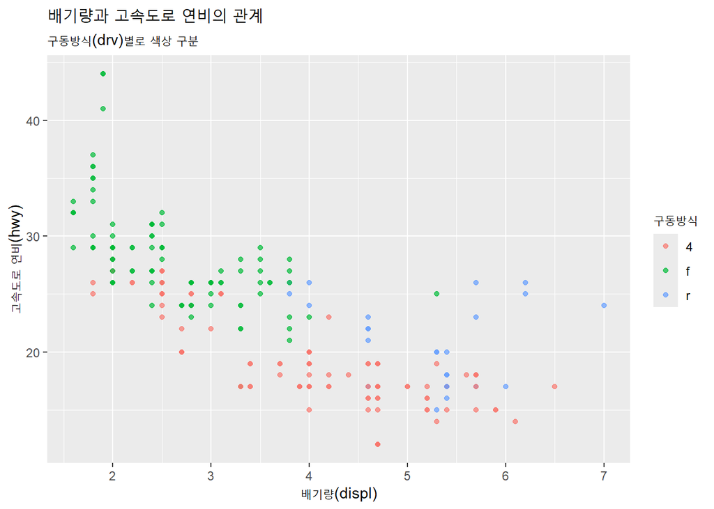

```r
ggplot(mpg, aes(x = displ, y = hwy, color = drv)) +
  geom_point(alpha = 0.7) +
  labs(
    title = "배기량과 고속도로 연비의 관계",
    subtitle = "구동방식(drv)별로 색상 구분",
    x = "배기량(displ)",
    y = "고속도로 연비(hwy)",
    color = "구동방식"
  )
```

## 4.8. 테마(theme): 전체 스타일 바꾸기

대표적으로 많이 쓰는 테마는 다음과 같다.

- `theme_minimal()`
- `theme_bw()`
- `theme_classic()`

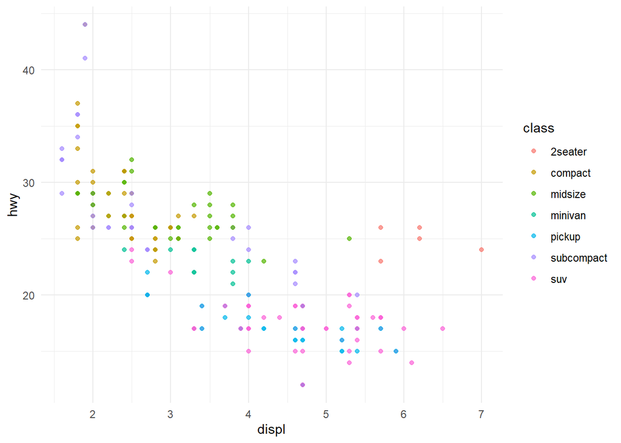

```r
ggplot(mpg, aes(x = displ, y = hwy, color = class)) +
  geom_point(alpha = 0.7) +
  theme_minimal()
```

## 4.9. 스케일(scale): 축 변환/범위 조정

### 4.9.1 y축 범위 제한(주의: 범위 밖 데이터는 잘린다)

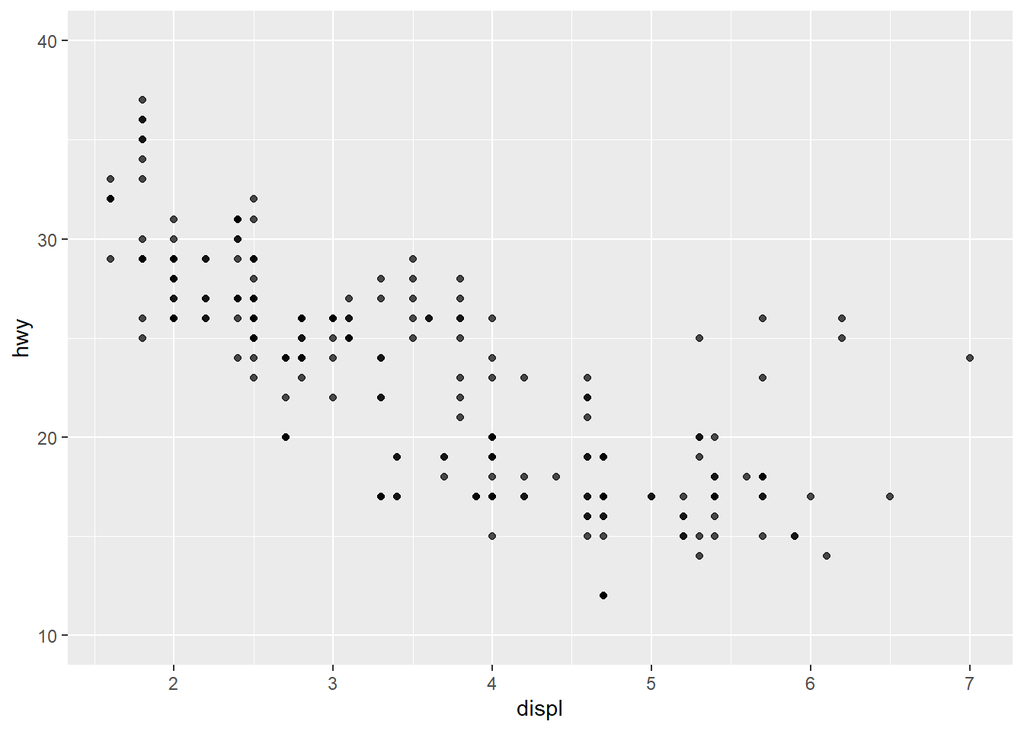

```r
ggplot(mpg, aes(x = displ, y = hwy)) +
  geom_point(alpha = 0.7) +
  scale_y_continuous(limits = c(10, 40))
```

### 4.9.2 로그 스케일(분포가 한쪽으로 치우친 경우)

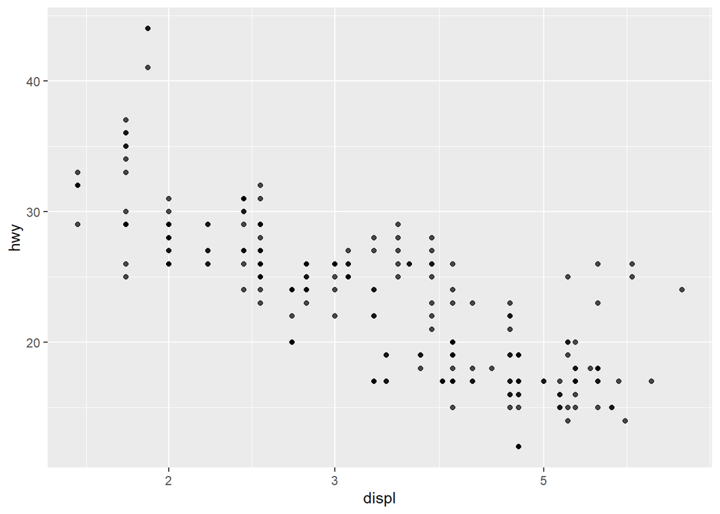

```r
ggplot(mpg, aes(x = displ, y = hwy)) +
  geom_point(alpha = 0.7) +
  scale_x_log10()
```

## 4.10. 저장하기: ggsave

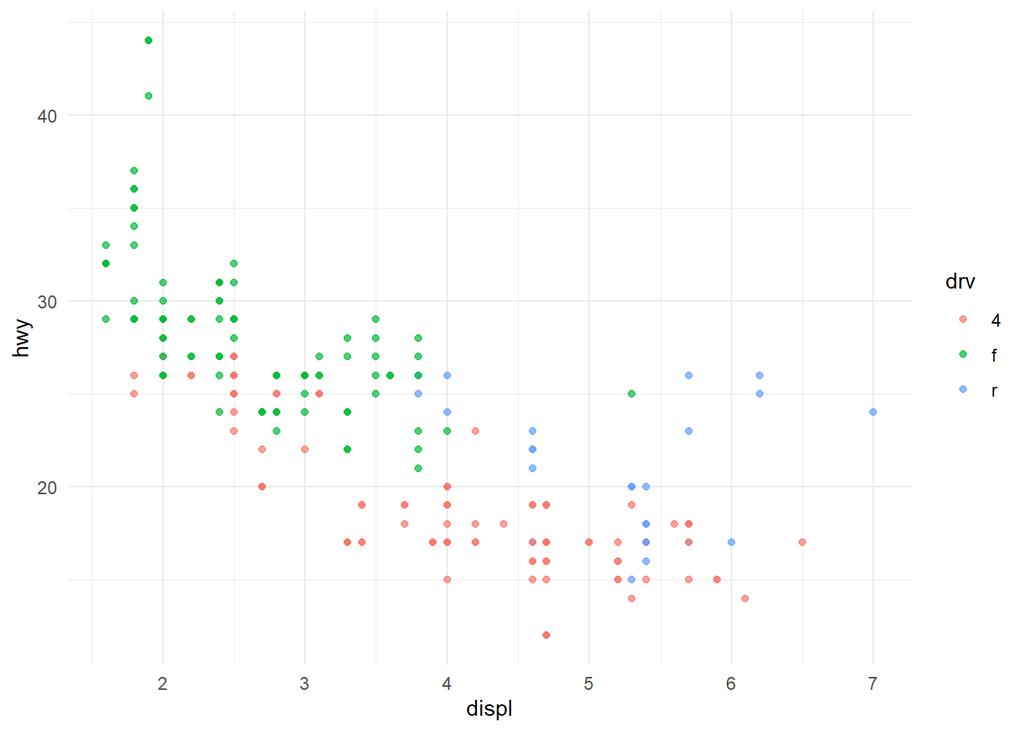

```r
p <- ggplot(mpg, aes(x = displ, y = hwy, color = drv)) +
  geom_point(alpha = 0.7) +
  theme_minimal()

p
```

```r
ggsave("mpg_scatter.png", plot = p, width = 7, height = 5, dpi = 300)
```

## 4.11. 연습문제

### 연습 1

`cty`(도심연비)와 `hwy`(고속도로연비)의 관계를 산점도로 그리고, `class`로 색을 구분해보자.

힌트: - `aes(x = cty, y = hwy, color = class)` - `geom_point()`

### 연습 2

`class`별 `hwy`의 분포를 박스플롯으로 그린 뒤, x축 레이블 겹침을 해결해보자.

힌트: - `theme(axis.text.x = element_text(angle = 45, hjust = 1))`

### 연습 3

`drv`별 평균 `hwy`를 계산한 뒤 막대그래프로 나타내보자.

힌트: - `group_by(drv) %>% summarise(mean_hwy = mean(hwy))` - `geom_col()`

## 요약

- `ggplot(data) + aes(...) + geom_*()`는 기본 뼈대다.
- `+`로 레이어를 쌓아 의미를 확장한다.
- 범주 비교는 `facet`, 스타일은 `theme`, 축/표현은 `scale`로 다룬다.
- 실무에서는 `dplyr`로 집계 후 `geom_col()` 조합을 자주 쓴다.

연습 1: cty vs hwy 산점도 + class로 색 구분 ggplot(mpg, aes(x = cty, y = hwy, color = class)) + geom_point(alpha = 0.7) + labs( title = “cty vs hwy (class로 색 구분)”, x = “cty (도심 연비)”, y = “hwy (고속도로 연비)”, color = “class” )

연습 2: class별 hwy 박스플롯 + x축 레이블 겹침 해결 ggplot(mpg, aes(x = class, y = hwy)) + geom_boxplot(outlier.alpha = 0.3) + theme(axis.text.x = element_text(angle = 45, hjust = 1)) + labs( title = “class별 hwy 분포(박스플롯)”, x = “class”, y = “hwy” )

연습 3: drv별 평균 hwy 계산 후 막대그래프(geom_col) mpg_drv <- mpg %>% group_by(drv) %>% summarise(mean_hwy = mean(hwy), .groups = “drop”)

ggplot(mpg_drv, aes(x = drv, y = mean_hwy)) + geom_col() + labs( title = “drv별 평균 hwy”, x = “drv”, y = “mean(hwy)” )

# 5. 국민체력 100 자료를 이용한 데이터 분석 예제

## 필요한 패키지

다음은 본 예제를 실행하는 데 필요한 R 패키지들이다. 패키지가 설치되어 있지 않은 경우에는 먼저 설치한 후 로드한다.

```r
library(tidyverse) # 데이터 처리 및 시각화 패키지
library(lubridate) # 날짜 처리 패키지
library(stringr) # 문자열 처리 패키지
library(readxl) # 엑셀 파일 읽기 위한 패키지
#library(openxlsx) # 엑셀 파일 읽기 위한 패키지
library(flextable) # 표 작성 패키지
library(here) # 파일 경로 설정을 위한 패키지

# ggplot 으로 그림을 그릴 때 한글이 깨지지 않게 폰트 Nanum Pen Script를 선택
library(showtext)
font_add_google("Nanum Pen Script", "gl")
showtext_auto()
```

## 개요

국민체력 100 사업은 국민의 기초체력을 증진시키기 위하여 국민체력 측정 및 평가, 운동처방, 체력증진 프로그램 운영 등을 실시하는 사업이다. 이 사업을 통해 수집된 자료는 국민의 체력 수준을 파악하고, 체력 증진을 위한 다양한 프로그램을 개발하는 데 활용된다. 본 예제에서는 국민체력 100 자료를 이용하여 데이터에 대한 전처리 및 기초 분석과 시각화를 수행하는 방법을 다룬다.

## 데이터 불러오기

### 데이터 파일 개요

**분위수란?**

분위수(quantile) 는 자료를 크기 순으로 정렬했을 때, 전체를 일정한 비율로 나누는 기준값을 말한다. 예를 들어 중앙값(50% 분위수) 은 자료의 절반이 그 값 이하가 되도록 하는 지점이며, 사분위수(25%, 50%, 75%) 는 자료를 네 구간으로 나누는 기준값이다. 분위수를 활용하면 평균처럼 일부 극단값의 영향을 크게 받지 않으면서도, 자료의 분포와 개인의 상대적 위치를 직관적으로 파악할 수 있다.

다음은 위에서 설명한 3개의 엑셀파일의 일부를 나타낸 그림이다.

Figure 7: 국민체력 100 사업의 측정 데이터

`sample_data_sports100.xlsx`

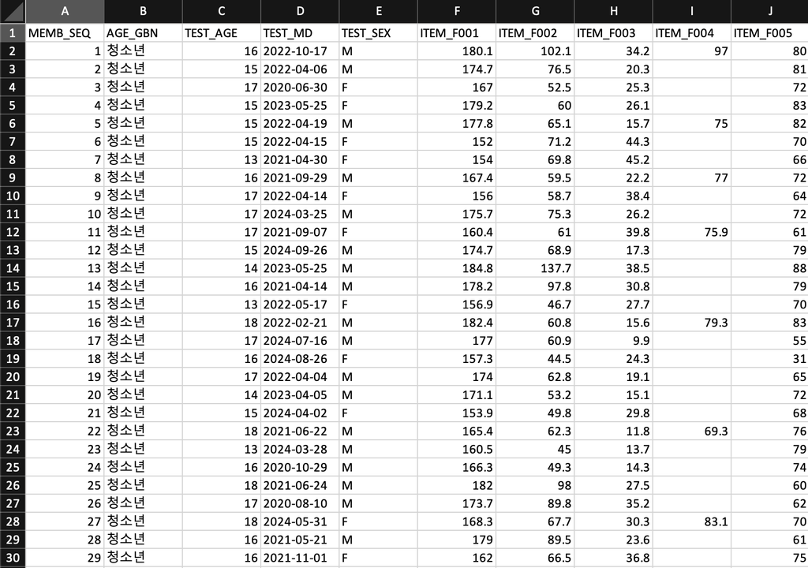

Figure 8: 국민체력 100 측정 데이터의 설명 자료

`column_info.xlsx`

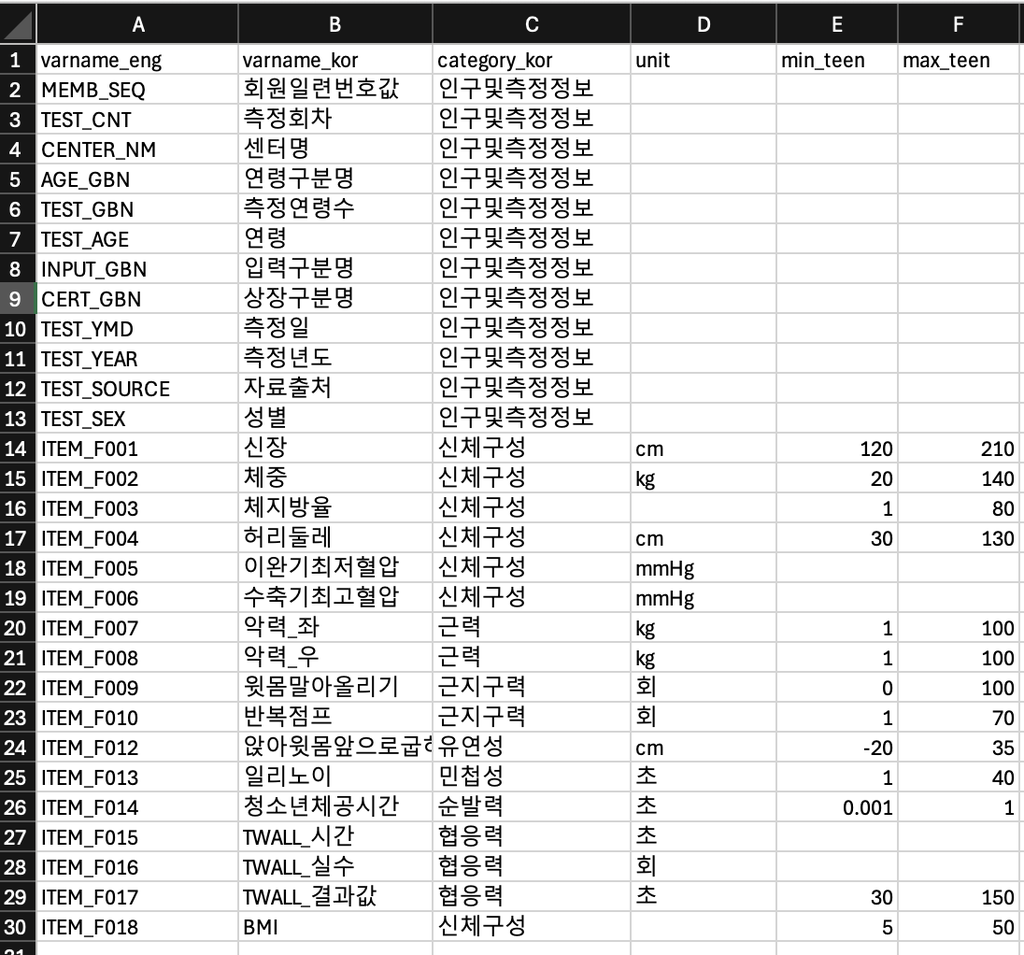

**변수 정보 자료**

많은 종류의 자료를 관리하는 경우 각 항목의 이름을 의미가 있는 영문명이나 한글명으로 관리하는 것은 복잡한 작업이다. 우리가 위에서 본 국민체력100에 대한 자료에서 관측값을 저장하는 `sample_data_sport100.xlsx` 에서는 변수명을 `ITEM_XXX` 와 같이 번호가 붙은 컬럼명을 사용한다.

더 나아가 별도의 자료 `columns_info.xlsx` 는 변수명 `ITEM_XXX` 에 대한 한글이름, 체력 측정에 대한 부문, 단위, 정상값 범위 등 측정항목에 대한 정보(즉 메타 정보; Meta Infomation)를 포함한다.

이렇게 측정값을 저장하는 데이터와 측정항목의 정보를 저장하는 데이터를 따로 관리하고 서료 결합할 수 있게 하면 자료의 확정성이 커지고 관리가 편리하다.

Figure 9: 국민체력 100 측정 데이터의 등급 기준 자료

`class_level.xlsx`

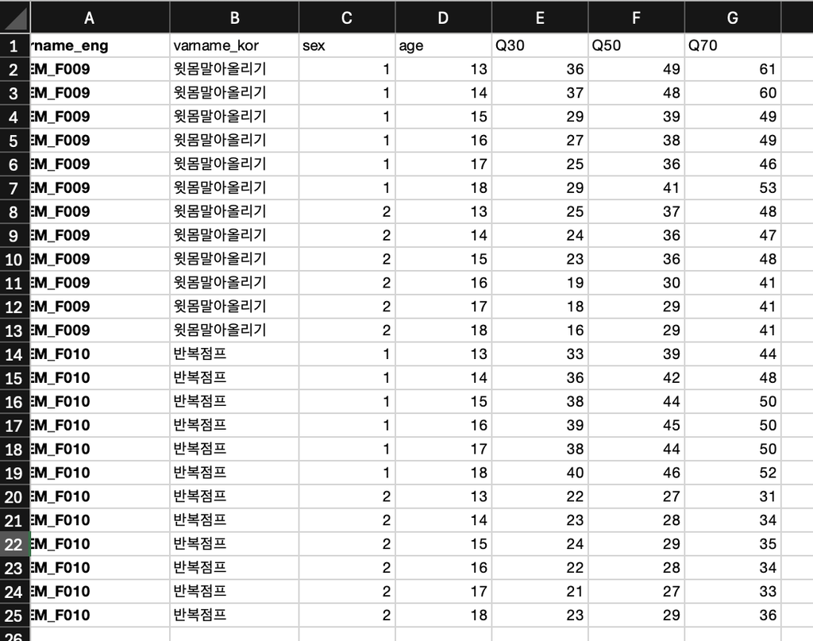

### 데이터 불러오기

이제 `R`을 이용하여 위에서 설명한 3 개의 엑셀 파일을 불러오자. 이를 위해 `readxl` 패키지의 함수 `read_xlsx`를 사용한다. 함수 `read_xlsx` 에서 사용된 `col_names = TRUE` 선택문은 엑셀파일의 첫 번째 행의 내용을 컬럼의 이름으로 하기위한 선택문이다.

```r
# 데이터 불러오기
df_data <- read_xlsx(here("data", "sample_data_sports100.xlsx"), col_names = TRUE)
df_col_info <- read_xlsx(here("data", "column_info.xlsx"), col_names = TRUE)
df_class_level <- read_xlsx(here("data", "class_level.xlsx"), col_names = TRUE)
```

**`here()` 함수 설명**

`here()` 함수는 R 프로젝트에서 파일 경로를 쉽게 관리할 수 있도록 도와주는 함수이다. 이 함수는 프로젝트의 루트 디렉토리를 기준으로 상대 경로를 생성하여, 파일을 불러오거나 저장할 때 편리하게 사용할 수 있다.

예를 들어, `here("data", "sample_data_sports100.xlsx")`는 현재 R 프로젝트의 루트 디렉토리에서 `data` 폴더 안에 있는 `sample_data_sports100.xlsx` 파일의 경로를 생성한다. 이를 통해 코드가 다른 컴퓨터나 환경에서 실행될 때도 파일 경로 문제를 최소화할 수 있다.

이제 불러온 자료의 일부와 구조를 살펴보면서 자료가 정확하게 데이터프레임으로 만들어졌는지 살펴보자.

```r
head(df_data)
```

```
# A tibble: 6 × 22
  MEMB_SEQ AGE_GBN TEST_AGE TEST_MD    TEST_SEX ITEM_F001 ITEM_F002 ITEM_F003
     <dbl> <chr>      <dbl> <chr>      <chr>        <dbl>     <dbl>     <dbl>
1        1 성인          59 2023-09-25 F             160.      51.5      24.6
2        2 청소년        17 2023-04-12 F             160.      75.8      46.4
3        3 성인          19 2022-05-18 F             163.      57.4      32
4        4 청소년        13 2022-05-11 F             157.      61.4      36.5
5        5 청소년        17 2024-06-20 F             169.      67.1      32.1
6        6 청소년        15 2022-09-19 M             165.      59.4      19.7
# ℹ 14 more variables: ITEM_F004 <dbl>, ITEM_F005 <dbl>, ITEM_F006 <dbl>,
#   ITEM_F007 <dbl>, ITEM_F008 <dbl>, ITEM_F009 <dbl>, ITEM_F010 <dbl>,
#   ITEM_F012 <dbl>, ITEM_F013 <dbl>, ITEM_F014 <dbl>, ITEM_F015 <dbl>,
#   ITEM_F016 <dbl>, ITEM_F017 <dbl>, ITEM_F018 <dbl>
```

```r
head(df_col_info)
```

```
# A tibble: 6 × 6
  varname_eng varname_kor    category_kor   unit  min_teen max_teen
  <chr>       <chr>          <chr>          <chr>    <dbl>    <dbl>
1 MEMB_SEQ    회원일련번호값 인구및측정정보 <NA>        NA       NA
2 TEST_CNT    측정회차       인구및측정정보 <NA>        NA       NA
3 CENTER_NM   센터명         인구및측정정보 <NA>        NA       NA
4 AGE_GBN     연령구분명     인구및측정정보 <NA>        NA       NA
5 TEST_GBN    측정연령수     인구및측정정보 <NA>        NA       NA
6 TEST_AGE    연령           인구및측정정보 <NA>        NA       NA
```

```r
head(df_class_level)
```

```
# A tibble: 6 × 7
  varname_eng varname_kor      sex   age   Q30   Q50   Q70
  <chr>       <chr>          <dbl> <dbl> <dbl> <dbl> <dbl>
1 ITEM_F009   윗몸말아올리기     1    13    36    49    61
2 ITEM_F009   윗몸말아올리기     1    14    37    48    60
3 ITEM_F009   윗몸말아올리기     1    15    29    39    49
4 ITEM_F009   윗몸말아올리기     1    16    27    38    49
5 ITEM_F009   윗몸말아올리기     1    17    25    36    46
6 ITEM_F009   윗몸말아올리기     1    18    29    41    53
```

## 데이터 전처리

먼저 함수 `glimpse` 을 이용하여 측정 자료 `df_data` 의 각 컬럼들이 어떠한 형식으로 입력되어 있는지 살펴보자

```r
glimpse(df_data)
```

```
Rows: 2,000
Columns: 22
$ MEMB_SEQ  <dbl> 1, 2, 3, 4, 5, 6, 7, 8, 9, 10, 11, 12, 13, 14, 15, 16, 17, 1…
$ AGE_GBN   <chr> "성인", "청소년", "성인", "청소년", "청소년", "청소년", "성인", "성인", "성인", "청…
$ TEST_AGE  <dbl> 59, 17, 19, 13, 17, 15, 46, 33, 38, 17, 16, 16, 22, 31, 17, …
$ TEST_MD   <chr> "2023-09-25", "2023-04-12", "2022-05-18", "2022-05-11", "202…
$ TEST_SEX  <chr> "F", "F", "F", "F", "F", "M", "M", "M", "M", "M", "M", "M", …
$ ITEM_F001 <dbl> 159.6, 159.8, 162.9, 157.4, 168.9, 165.4, 177.1, 174.9, 169.…
$ ITEM_F002 <dbl> 51.5, 75.8, 57.4, 61.4, 67.1, 59.4, 81.1, 78.3, 74.7, 53.7, …
$ ITEM_F003 <dbl> 24.6, 46.4, 32.0, 36.5, 32.1, 19.7, 19.1, 24.9, 28.0, 10.3, …
$ ITEM_F004 <dbl> NA, NA, 80.7, NA, NA, NA, NA, 90.4, 94.6, 63.0, 78.0, NA, 73…
$ ITEM_F005 <dbl> 68, 71, 95, 0, 62, 70, 65, 89, 85, 75, 41, 66, 51, 79, 68, 8…
$ ITEM_F006 <dbl> 120, 130, 143, 0, 104, 117, 110, 125, 122, 115, 111, 121, 91…
$ ITEM_F007 <dbl> 23.4, 31.2, 21.8, 28.0, 24.9, 39.4, 47.0, 40.1, 42.9, 36.0, …
$ ITEM_F008 <dbl> 23.8, 34.2, 23.8, 30.0, 29.9, 39.4, 48.2, 48.2, 49.1, 39.1, …
$ ITEM_F009 <dbl> NA, NA, NA, NA, 21, NA, NA, NA, NA, 23, 46, NA, NA, NA, 22, …
$ ITEM_F010 <dbl> NA, 15, NA, NA, NA, 43, NA, NA, NA, NA, NA, 53, NA, NA, NA, …
$ ITEM_F012 <dbl> 4.2, 23.8, -4.6, 16.8, 19.0, 11.3, 12.2, 11.9, 16.6, 10.8, 7…
$ ITEM_F013 <dbl> NA, 30.00, NA, 24.09, 20.12, 17.83, NA, NA, NA, 17.47, 16.80…
$ ITEM_F014 <dbl> NA, 0.378, NA, 0.440, 0.477, 0.551, NA, NA, NA, 0.647, 0.626…
$ ITEM_F015 <dbl> NA, 54.295, NA, NA, 53.065, 44.907, NA, NA, NA, 38.894, 41.0…
$ ITEM_F016 <dbl> NA, 11, NA, NA, 5, 3, NA, NA, NA, 15, 7, 6, NA, NA, 5, NA, 5…
$ ITEM_F017 <dbl> NA, 54.801, NA, NA, 53.295, 45.045, NA, NA, NA, 39.584, 41.3…
$ ITEM_F018 <dbl> 20.2, 29.7, 21.6, 24.8, 23.5, 21.7, 25.9, 25.6, 25.9, 17.5, …
```

먼저 연령을 나타내는 컬럼 `TEST_AGE` 가 실수형(double)으로 입력되어 있으므로 편의상 정수형(integer) 로 변환하자.

```r
df_data <- df_data %>%
  mutate( TEST_AGE = as.integer(TEST_AGE))
```

### 날짜 변수의 생성

먼저 데이터프레임 `df_data` 에서 `TEST_MD` 컬럼은 측정 날짜를 나타내는 데이터이지만 엑셀 파일에서 자료 입력시 문자형 변수로 입력이 된다. 일반적으로 날짜를 나타내는 자료는 날짜형 변수로 형식을 바꾸는 것이 다루기 편하다.

```r
glimpse(df_data$TEST_MD)
```

```
 chr [1:2000] "2023-09-25" "2023-04-12" "2022-05-18" "2022-05-11" ...
```

```r
df_data <- df_data %>%
  mutate(
    TEST_MD = ymd(TEST_MD)
  )

glimpse(df_data$TEST_MD)
```

```
 Date[1:2000], format: "2023-09-25" "2023-04-12" "2022-05-18" "2022-05-11" "2024-06-20" ...
```

다음으로 측정 년도를 나타내는 새로운 변수 `TEST_YEAR` 를 함수 `year` 를 이용하여 생성하고, 다시 범주형으로 변환하여 컬럼의 위치를 `TEST_MD` 뒤에 있도록 하자. 일반적으로 년도를 나타내는 변수는 정수형이지만 범주형으로 사용하는 것이 편리하다.

```r
df_data <- df_data %>%
  mutate(TEST_YEAR = factor(year(TEST_MD))) %>%
  relocate(TEST_YEAR, .after = TEST_MD)
```

### 범주형 변수의 변환

다음으로 성별을 나타내는 `TEST_SEX` 변수의 값이 `M`이면 `남성`, `F`이면 `여성` 으로 문자형으로 바꾸고 범주형 변수(factor)로 변환하자.

또한 생애 주기를 나타내는 변수 `AGE_GBN` 범주형 변수로 변환하자. 이 경우 `levels` 선택문을 사용하여 항목의 순서를 `청소년`, `성인`, `어르신` 순서로 지정할 수 있다.

```r
df_data <- df_data %>%
  mutate(TEST_SEX = case_when(
      TEST_SEX == "M" ~ "남성",
      TEST_SEX == "F" ~ "여성")) %>%
  mutate( TEST_SEX = factor(TEST_SEX, levels = c("남성", "여성"))) %>%
  mutate( AGE_GBN = factor(AGE_GBN, levels = c("청소년", "성인",   "어르신")))

glimpse(df_data)
```

```
Rows: 2,000
Columns: 23
$ MEMB_SEQ  <dbl> 1, 2, 3, 4, 5, 6, 7, 8, 9, 10, 11, 12, 13, 14, 15, 16, 17, 1…
$ AGE_GBN   <fct> 성인, 청소년, 성인, 청소년, 청소년, 청소년, 성인, 성인, 성인, 청소년, 청소년, 청소년, 성인, 성…
$ TEST_AGE  <int> 59, 17, 19, 13, 17, 15, 46, 33, 38, 17, 16, 16, 22, 31, 17, …
$ TEST_MD   <date> 2023-09-25, 2023-04-12, 2022-05-18, 2022-05-11, 2024-06-20,…
$ TEST_YEAR <fct> 2023, 2023, 2022, 2022, 2024, 2022, 2022, 2020, 2020, 2021, …
$ TEST_SEX  <fct> 여성, 여성, 여성, 여성, 여성, 남성, 남성, 남성, 남성, 남성, 남성, 남성, 여성, 남성, 남성, …
$ ITEM_F001 <dbl> 159.6, 159.8, 162.9, 157.4, 168.9, 165.4, 177.1, 174.9, 169.…
$ ITEM_F002 <dbl> 51.5, 75.8, 57.4, 61.4, 67.1, 59.4, 81.1, 78.3, 74.7, 53.7, …
$ ITEM_F003 <dbl> 24.6, 46.4, 32.0, 36.5, 32.1, 19.7, 19.1, 24.9, 28.0, 10.3, …
$ ITEM_F004 <dbl> NA, NA, 80.7, NA, NA, NA, NA, 90.4, 94.6, 63.0, 78.0, NA, 73…
$ ITEM_F005 <dbl> 68, 71, 95, 0, 62, 70, 65, 89, 85, 75, 41, 66, 51, 79, 68, 8…
$ ITEM_F006 <dbl> 120, 130, 143, 0, 104, 117, 110, 125, 122, 115, 111, 121, 91…
$ ITEM_F007 <dbl> 23.4, 31.2, 21.8, 28.0, 24.9, 39.4, 47.0, 40.1, 42.9, 36.0, …
$ ITEM_F008 <dbl> 23.8, 34.2, 23.8, 30.0, 29.9, 39.4, 48.2, 48.2, 49.1, 39.1, …
$ ITEM_F009 <dbl> NA, NA, NA, NA, 21, NA, NA, NA, NA, 23, 46, NA, NA, NA, 22, …
$ ITEM_F010 <dbl> NA, 15, NA, NA, NA, 43, NA, NA, NA, NA, NA, 53, NA, NA, NA, …
$ ITEM_F012 <dbl> 4.2, 23.8, -4.6, 16.8, 19.0, 11.3, 12.2, 11.9, 16.6, 10.8, 7…
$ ITEM_F013 <dbl> NA, 30.00, NA, 24.09, 20.12, 17.83, NA, NA, NA, 17.47, 16.80…
$ ITEM_F014 <dbl> NA, 0.378, NA, 0.440, 0.477, 0.551, NA, NA, NA, 0.647, 0.626…
$ ITEM_F015 <dbl> NA, 54.295, NA, NA, 53.065, 44.907, NA, NA, NA, 38.894, 41.0…
$ ITEM_F016 <dbl> NA, 11, NA, NA, 5, 3, NA, NA, NA, 15, 7, 6, NA, NA, 5, NA, 5…
$ ITEM_F017 <dbl> NA, 54.801, NA, NA, 53.295, 45.045, NA, NA, NA, 39.584, 41.3…
$ ITEM_F018 <dbl> 20.2, 29.7, 21.6, 24.8, 23.5, 21.7, 25.9, 25.6, 25.9, 17.5, …
```

**`case_when` 함수 설명**

`case_when()`은 여러 조건에 따라 값을 나누어 지정할 때 사용하는 함수이다. 조건문을 여러 번 쓰는 대신, 조건을 위에서부터 순서대로 검사하여 **처음으로 TRUE가 되는 값**을 반환한다.

## 기술 통계 분석

### 범주형 자료의 분포

먼저 2000명의 사랍들을 연도별, 성별, 생애주기별 도수 분포표를 만들어 보자. 가장 기본적인 범주형 자료의 분포를 만들 수 있는 함수는 `table` 함수이다.

```r
table(df_data$TEST_YEAR)
```

```
2020 2021 2022 2023 2024
 173  332  484  524  487
```

```r
table(df_data$TEST_SEX)
```

```
남성 여성
1246  754
```

```r
table(df_data$AGE_GBN)
```

```
청소년   성인 어르신
   847   1128     25
```

다음과 같이 함수 `table` 을 이용하여 2개의 변수에 대한 교차표(cross table) 도 만들 수 있다.

```r
table( df_data$TEST_SEX, df_data$TEST_YEAR)
```

```
       2020 2021 2022 2023 2024
  남성  124  210  298  318  296
  여성   49  122  186  206  191
```

`table` 함수로 만든 교차표를 데이터프레임으로 바꾸면 다음과 같은 형식의 자료가 생성된다.

```r
as.data.frame( table( df_data$TEST_SEX, df_data$TEST_YEAR))
```

```
   Var1 Var2 Freq
1  남성 2020  124
2  여성 2020   49
3  남성 2021  210
4  여성 2021  122
5  남성 2022  298
6  여성 2022  186
7  남성 2023  318
8  여성 2023  206
9  남성 2024  296
10 여성 2024  191
```

`table` 함수는 간단하게 범주형 변수의 분포를 파악하는 데 유용하지만, `dplyr` 패키지를 이용하면 보다 유연하게 다양한 형태의 요약표를 만들 수 있다. 이제 `dplyr` 패키지의 `group_by` 와 `summarise` 함수를 이용하여 범주형 변수의 분포를 요약한 표를 만들어 보자. 교차표에 연도별 남녀의 비율을 추가하는 코드도 추가해보자.

```r
cross_tbl_01 <- df_data %>%
  group_by(TEST_YEAR, TEST_SEX) %>%
  summarise(n = n(), .groups = "drop_last") %>%
  mutate(percent = n / sum(n) * 100 )

cross_tbl_01
```

```
# A tibble: 10 × 4
# Groups:   TEST_YEAR [5]
   TEST_YEAR TEST_SEX     n percent
   <fct>     <fct>    <int>   <dbl>
 1 2020      남성       124    71.7
 2 2020      여성        49    28.3
 3 2021      남성       210    63.3
 4 2021      여성       122    36.7
 5 2022      남성       298    61.6
 6 2022      여성       186    38.4
 7 2023      남성       318    60.7
 8 2023      여성       206    39.3
 9 2024      남성       296    60.8
10 2024      여성       191    39.2
```

**`summarise()` 함수의 `.groups` 인자 설명**

`summarise()` 함수의 `.groups` 인자는 요약된 결과 데이터프레임에서 그룹화된 변수를 어떻게 처리할지를 지정하는 역할을 한다. 이 인자는 다음과 같은 옵션들을 가질 수 있다:

- `"drop"`: 모든 그룹화를 제거하고 결과를 단일 데이터프레임으로 반환한다.
- `"drop_last"`: 마지막 그룹화 변수만 제거하고 나머지 그룹화 변수는 유지한다.
- `"keep"`: 모든 그룹화 변수를 유지한다.
- `"rowwise"`: 결과를 행 단위로 그룹화한다.

```r
cross_tbl_02 <- df_data %>%
  group_by(TEST_YEAR, TEST_SEX) %>%
  summarise( n = n(), .groups = "drop") %>%
  mutate( percent = n / sum(n) * 100 )

cross_tbl_02
```

```
# A tibble: 10 × 4
   TEST_YEAR TEST_SEX     n percent
   <fct>     <fct>    <int>   <dbl>
 1 2020      남성       124    6.2
 2 2020      여성        49    2.45
 3 2021      남성       210   10.5
 4 2021      여성       122    6.1
 5 2022      남성       298   14.9
 6 2022      여성       186    9.3
 7 2023      남성       318   15.9
 8 2023      여성       206   10.3
 9 2024      남성       296   14.8
10 2024      여성       191    9.55
```

### 연속형 자료의 요약

다음으로 연속형 변수들의 요약 통계량을 계산해 보자. 이를 위해 `dplyr` 패키지의 `summarise` 함수를 이용하여 각 변수에 대한 평균, 표준편차, 최소값, 최대값 등을 계산할 수 있다. 예를 들어, 연도별, 성별로 신장(`ITEM_F001`)에 대한 요약 통계량을 계산하는 코드는 다음과 같다.

```r
summary_stats_1 <- df_data %>%
   group_by(TEST_YEAR, TEST_SEX) %>%
  summarise(
    height_mean = mean(ITEM_F001, na.rm = TRUE),
    height_sd = sd(ITEM_F001, na.rm = TRUE),
     .groups = "keep")

summary_stats_1
```

```
# A tibble: 10 × 4
# Groups:   TEST_YEAR, TEST_SEX [10]
   TEST_YEAR TEST_SEX height_mean height_sd
   <fct>     <fct>          <dbl>     <dbl>
 1 2020      남성            174.      5.98
 2 2020      여성            161.      5.07
 3 2021      남성            173.      6.31
 4 2021      여성            160.      6.17
 5 2022      남성            173.      6.09
 6 2022      여성            161.      5.42
 7 2023      남성            173.      6.13
 8 2023      여성            161.      6.32
 9 2024      남성            173.      6.48
10 2024      여성            161.      5.47
```

더 나아가 여러 개의 변수들에 대하여 요약 통계량을 한꺼번에 계산하려면 `across` 함수를 사용할 수 있다. 예를 들어, 신장(`ITEM_F001`), 몸무게(`ITEM_F002`), 체지방률(`ITEM_F003`)에 대한 요약 통계량을 한꺼번에 계산하는 코드는 다음과 같다.

```r
summary_stats_2 <- df_data %>%
  group_by(TEST_YEAR, TEST_SEX) %>%
  summarise(
    across(c(ITEM_F001, ITEM_F002, ITEM_F003),
      list(mean = ~ mean(.x, na.rm = TRUE),
           sd = ~ sd(.x, na.rm = TRUE),
           min = ~ min(.x, na.rm = TRUE),
           max = ~ max(.x, na.rm = TRUE)
      ),
    .names = "{.col}-{.fn}"
    ),
    .groups = "keep"
  )

summary_stats_2
```

```
# A tibble: 10 × 14
# Groups:   TEST_YEAR, TEST_SEX [10]
   TEST_YEAR TEST_SEX `ITEM_F001-mean` `ITEM_F001-sd` `ITEM_F001-min`
   <fct>     <fct>               <dbl>          <dbl>           <dbl>
 1 2020      남성                 174.           5.98            156.
 2 2020      여성                 161.           5.07            149.
 3 2021      남성                 173.           6.31            157.
 4 2021      여성                 160.           6.17            144.
 5 2022      남성                 173.           6.09            154.
 6 2022      여성                 161.           5.42            144.
 7 2023      남성                 173.           6.13            147.
 8 2023      여성                 161.           6.32            134.
 9 2024      남성                 173.           6.48            152
10 2024      여성                 161.           5.47            144.
# ℹ 9 more variables: `ITEM_F001-max` <dbl>, `ITEM_F002-mean` <dbl>,
#   `ITEM_F002-sd` <dbl>, `ITEM_F002-min` <dbl>, `ITEM_F002-max` <dbl>,
#   `ITEM_F003-mean` <dbl>, `ITEM_F003-sd` <dbl>, `ITEM_F003-min` <dbl>,
#   `ITEM_F003-max` <dbl>
```

**`flextable` 의 이용**

데이터프레임을 출력하는 경우 표 형식(tbale format)으로 보기 좋게 출력하려면 `flextable` 함수를 사용하면 된다. 패키지 `flextable` 포함된 `flextable` 과 `autofit` 두 함수를 사용하면 보기 편한 표 형식으로 데이터를 출력할 수 있다.

이제 위에서 구한 데이터프레임 `summary_stats_2` 의 일부를 `flextable` 함수를 이용하여 출력해보자.

```r
head(summary_stats_2, 20) %>%
  flextable() %>%
  autofit()
```

| TEST_YEAR | TEST_SEX | ITEM_F001-mean | ITEM_F001-sd | ITEM_F001-min | ITEM_F001-max | ITEM_F002-mean | ITEM_F002-sd | ITEM_F002-min | ITEM_F002-max | ITEM_F003-mean | ITEM_F003-sd | ITEM_F003-min | ITEM_F003-max |
| --- | --- | --- | --- | --- | --- | --- | --- | --- | --- | --- | --- | --- | --- |
| 2020 | 남성 | 173.9427 | 5.977616 | 155.5 | 193.0 | 74.12484 | 11.345773 | 49.7 | 107.2 | 20.95726 | 6.809835 | 7.4 | 43.5 |
| 2020 | 여성 | 160.6510 | 5.069686 | 149.1 | 172.0 | 57.45633 | 9.193971 | 43.7 | 84.5 | 30.20497 | 6.715810 | 19.1 | 44.9 |
| 2021 | 남성 | 172.9919 | 6.312112 | 157.4 | 193.0 | 72.64895 | 14.359963 | 40.9 | 124.5 | 22.04238 | 8.027963 | 5.2 | 45.0 |
| 2021 | 여성 | 160.1557 | 6.172922 | 144.2 | 177.0 | 58.89689 | 11.494071 | 35.9 | 107.6 | 32.14918 | 7.122369 | 10.4 | 47.3 |
| 2022 | 남성 | 173.0534 | 6.088451 | 154.4 | 188.9 | 72.80174 | 13.175140 | 37.3 | 128.3 | 21.92617 | 7.427525 | 5.9 | 46.0 |
| 2022 | 여성 | 161.0796 | 5.415904 | 143.6 | 174.8 | 58.33634 | 10.427121 | 29.6 | 104.0 | 31.77366 | 7.462106 | 3.0 | 51.4 |
| 2023 | 남성 | 172.9814 | 6.130037 | 147.2 | 192.8 | 73.33478 | 13.438897 | 39.0 | 127.0 | 21.79748 | 7.682271 | 5.3 | 48.7 |
| 2023 | 여성 | 160.5272 | 6.324219 | 133.8 | 178.0 | 57.81316 | 9.322815 | 42.0 | 87.6 | 31.20732 | 6.499939 | 15.9 | 50.1 |
| 2024 | 남성 | 173.0473 | 6.481655 | 152.0 | 191.8 | 73.06811 | 14.646761 | 37.8 | 138.5 | 21.20608 | 7.498404 | 4.8 | 45.0 |
| 2024 | 여성 | 161.4021 | 5.467608 | 143.8 | 175.0 | 58.19319 | 11.220433 | 40.8 | 106.7 | 30.74377 | 7.356021 | 12.7 | 52.0 |

### 자료의 형태 변환

**넓은 형식와 긴 형식의 자료**

- **넓은 형식의 자료(wide format data)**
  - 하나의 개체에 해당하는 값들이 한 행으로 구성
  - 보고서 및 요약표 작성에 적합

Figure 10: 넓은 형식의 자료

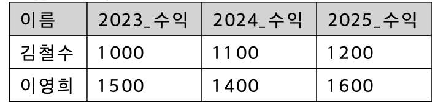

- **긴 형식의 자료(long format data)**
  - 하나의 개체에 해당하는 값들이 여러 개의 행으로 구성
  - 통계 분석 및 시계열 분석에 적합

Figure 11: 긴 형식의 자료

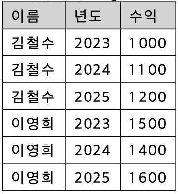

두 형식은 두 함수 `pivot_wider` 와 `pivot_longer` 로 서로 변환할 수 있다.

위의 결과는 각 변수의 통계량(평균, 표준편차, 최소값, 최대값)이 컬럼 형태로 저장된 **넓은 형태의 자료(wide format data)**이다. 이제 통계량의 값을 하나의 컬럼에 저장하는 **긴 형태의 자료(long format data)** 로 바꾸어 보자. 이를 위해 `pivot_longer` 함수를 사용한다.

```r
summary_stats_3 <- summary_stats_2 %>%
  pivot_longer(
    cols = starts_with("ITEM"),
    names_sep = "-",
    names_to = c("varname_eng", "stat"),
    values_to = "value"
  )

head(summary_stats_3, 20) %>%
  flextable() %>%
  autofit()
```

| TEST_YEAR | TEST_SEX | varname_eng | stat | value |
| --- | --- | --- | --- | --- |
| 2020 | 남성 | ITEM_F001 | mean | 173.942742 |
| 2020 | 남성 | ITEM_F001 | sd | 5.977616 |
| 2020 | 남성 | ITEM_F001 | min | 155.500000 |
| 2020 | 남성 | ITEM_F001 | max | 193.000000 |
| 2020 | 남성 | ITEM_F002 | mean | 74.124839 |
| 2020 | 남성 | ITEM_F002 | sd | 11.345773 |
| 2020 | 남성 | ITEM_F002 | min | 49.700000 |
| 2020 | 남성 | ITEM_F002 | max | 107.200000 |
| 2020 | 남성 | ITEM_F003 | mean | 20.957258 |
| 2020 | 남성 | ITEM_F003 | sd | 6.809835 |
| 2020 | 남성 | ITEM_F003 | min | 7.400000 |
| 2020 | 남성 | ITEM_F003 | max | 43.500000 |
| 2020 | 여성 | ITEM_F001 | mean | 160.651020 |
| 2020 | 여성 | ITEM_F001 | sd | 5.069686 |
| 2020 | 여성 | ITEM_F001 | min | 149.100000 |
| 2020 | 여성 | ITEM_F001 | max | 172.000000 |
| 2020 | 여성 | ITEM_F002 | mean | 57.456327 |
| 2020 | 여성 | ITEM_F002 | sd | 9.193971 |
| 2020 | 여성 | ITEM_F002 | min | 43.700000 |
| 2020 | 여성 | ITEM_F002 | max | 84.500000 |

### 재코딩 및 변수 이름 바꾸기

다음으로 긴 형태의 자료(long format data)에서 `ITEM` 변수에 저장된 측정 항목의 변수명을 `df_col_info` 에 저장된 한글 측정 항목의 이름으로 바꾸어 작업을 다음과 같이 할 수 있다.

먼저 `df_col_info` 에서 영문 항목 이름(`varname_eng`) 과 한글 항목 이름(`varname_kor`) 를 선택하고 위에서 만든 `summary_stats_3` 에 있는 영문 항목 이름을 기준으로 결합을 한다.

```r
df_var_names <- df_col_info %>%
  select( varname_eng , varname_kor)

summary_stats_4 <- summary_stats_3 %>%
  left_join( df_var_names,
    by = "varname_eng")

head(summary_stats_4, 20) %>%
  flextable() %>%
  autofit()
```

| TEST_YEAR | TEST_SEX | varname_eng | stat | value | varname_kor |
| --- | --- | --- | --- | --- | --- |
| 2020 | 남성 | ITEM_F001 | mean | 173.942742 | 신장 |
| 2020 | 남성 | ITEM_F001 | sd | 5.977616 | 신장 |
| 2020 | 남성 | ITEM_F001 | min | 155.500000 | 신장 |
| 2020 | 남성 | ITEM_F001 | max | 193.000000 | 신장 |
| 2020 | 남성 | ITEM_F002 | mean | 74.124839 | 체중 |
| 2020 | 남성 | ITEM_F002 | sd | 11.345773 | 체중 |
| 2020 | 남성 | ITEM_F002 | min | 49.700000 | 체중 |
| 2020 | 남성 | ITEM_F002 | max | 107.200000 | 체중 |
| 2020 | 남성 | ITEM_F003 | mean | 20.957258 | 체지방율 |
| 2020 | 남성 | ITEM_F003 | sd | 6.809835 | 체지방율 |
| 2020 | 남성 | ITEM_F003 | min | 7.400000 | 체지방율 |
| 2020 | 남성 | ITEM_F003 | max | 43.500000 | 체지방율 |
| 2020 | 여성 | ITEM_F001 | mean | 160.651020 | 신장 |
| 2020 | 여성 | ITEM_F001 | sd | 5.069686 | 신장 |
| 2020 | 여성 | ITEM_F001 | min | 149.100000 | 신장 |
| 2020 | 여성 | ITEM_F001 | max | 172.000000 | 신장 |
| 2020 | 여성 | ITEM_F002 | mean | 57.456327 | 체중 |
| 2020 | 여성 | ITEM_F002 | sd | 9.193971 | 체중 |
| 2020 | 여성 | ITEM_F002 | min | 43.700000 | 체중 |
| 2020 | 여성 | ITEM_F002 | max | 84.500000 | 체중 |

이제 한글 항목 이름(`varname_kor`)의 위치를 변경하고 영문 항목 이름(`varname_eng`)를 제거하면 연도별, 성별로 각 측정항목에 대한 기초통계를 나타내는 데이터 프레임을 만들 수 있다.

```r
summary_stats_5 <- summary_stats_4 %>%
  select( -varname_eng) %>%
  relocate( varname_kor, .before = stat)

head(summary_stats_5, 20) %>%
  flextable() %>%
  autofit()
```

| TEST_YEAR | TEST_SEX | varname_kor | stat | value |
| --- | --- | --- | --- | --- |
| 2020 | 남성 | 신장 | mean | 173.942742 |
| 2020 | 남성 | 신장 | sd | 5.977616 |
| 2020 | 남성 | 신장 | min | 155.500000 |
| 2020 | 남성 | 신장 | max | 193.000000 |
| 2020 | 남성 | 체중 | mean | 74.124839 |
| 2020 | 남성 | 체중 | sd | 11.345773 |
| 2020 | 남성 | 체중 | min | 49.700000 |
| 2020 | 남성 | 체중 | max | 107.200000 |
| 2020 | 남성 | 체지방율 | mean | 20.957258 |
| 2020 | 남성 | 체지방율 | sd | 6.809835 |
| 2020 | 남성 | 체지방율 | min | 7.400000 |
| 2020 | 남성 | 체지방율 | max | 43.500000 |
| 2020 | 여성 | 신장 | mean | 160.651020 |
| 2020 | 여성 | 신장 | sd | 5.069686 |
| 2020 | 여성 | 신장 | min | 149.100000 |
| 2020 | 여성 | 신장 | max | 172.000000 |
| 2020 | 여성 | 체중 | mean | 57.456327 |
| 2020 | 여성 | 체중 | sd | 9.193971 |
| 2020 | 여성 | 체중 | min | 43.700000 |
| 2020 | 여성 | 체중 | max | 84.500000 |

위와 같이 컬럼에 포함된 자료의 내용을 바꾸는 작업은 함수 `case_match` 를 사용할 수도 있다. 예를 들어 위의 요약 통계량을 포함한 데이터프레임에서 통계량의 이름에 대한 컬럼(`stat`)에서 영문 통계량 이름을 다음과 같은 코드로 한글로 바꿀수 있다.

```r
final_summary_stats <- summary_stats_5 %>%
  mutate( stat = case_match( stat,
        "mean" ~ "평균",
        "sd" ~ "표준편차",
        "min" ~ "최소값",
        "max" ~ "최대값"))

head(final_summary_stats, 20) %>%
  flextable() %>%
  autofit()
```

| TEST_YEAR | TEST_SEX | varname_kor | stat | value |
| --- | --- | --- | --- | --- |
| 2020 | 남성 | 신장 | 평균 | 173.942742 |
| 2020 | 남성 | 신장 | 표준편차 | 5.977616 |
| 2020 | 남성 | 신장 | 최소값 | 155.500000 |
| 2020 | 남성 | 신장 | 최대값 | 193.000000 |
| 2020 | 남성 | 체중 | 평균 | 74.124839 |
| 2020 | 남성 | 체중 | 표준편차 | 11.345773 |
| 2020 | 남성 | 체중 | 최소값 | 49.700000 |
| 2020 | 남성 | 체중 | 최대값 | 107.200000 |
| 2020 | 남성 | 체지방율 | 평균 | 20.957258 |
| 2020 | 남성 | 체지방율 | 표준편차 | 6.809835 |
| 2020 | 남성 | 체지방율 | 최소값 | 7.400000 |
| 2020 | 남성 | 체지방율 | 최대값 | 43.500000 |
| 2020 | 여성 | 신장 | 평균 | 160.651020 |
| 2020 | 여성 | 신장 | 표준편차 | 5.069686 |
| 2020 | 여성 | 신장 | 최소값 | 149.100000 |
| 2020 | 여성 | 신장 | 최대값 | 172.000000 |
| 2020 | 여성 | 체중 | 평균 | 57.456327 |
| 2020 | 여성 | 체중 | 표준편차 | 9.193971 |
| 2020 | 여성 | 체중 | 최소값 | 43.700000 |
| 2020 | 여성 | 체중 | 최대값 | 84.500000 |

이제 최종적으로 각 컬럼의 이름을 한글로 바꾸면 다음과 같은 연도별, 성별로 각 측정항목에 대한 기초통계를 나타내는 데이터 프레임을 만들 수 있다.

```r
final_summary_stats <- final_summary_stats %>%
  rename( 년도 = TEST_YEAR,
          성별 = TEST_SEX,
          측정항목 = varname_kor,
          통계량 = stat,
          값 = value)

head(final_summary_stats, 20) %>%
  flextable() %>%
  autofit()
```

| 년도 | 성별 | 측정항목 | 통계량 | 값 |
| --- | --- | --- | --- | --- |
| 2020 | 남성 | 신장 | 평균 | 173.942742 |
| 2020 | 남성 | 신장 | 표준편차 | 5.977616 |
| 2020 | 남성 | 신장 | 최소값 | 155.500000 |
| 2020 | 남성 | 신장 | 최대값 | 193.000000 |
| 2020 | 남성 | 체중 | 평균 | 74.124839 |
| 2020 | 남성 | 체중 | 표준편차 | 11.345773 |
| 2020 | 남성 | 체중 | 최소값 | 49.700000 |
| 2020 | 남성 | 체중 | 최대값 | 107.200000 |
| 2020 | 남성 | 체지방율 | 평균 | 20.957258 |
| 2020 | 남성 | 체지방율 | 표준편차 | 6.809835 |
| 2020 | 남성 | 체지방율 | 최소값 | 7.400000 |
| 2020 | 남성 | 체지방율 | 최대값 | 43.500000 |
| 2020 | 여성 | 신장 | 평균 | 160.651020 |
| 2020 | 여성 | 신장 | 표준편차 | 5.069686 |
| 2020 | 여성 | 신장 | 최소값 | 149.100000 |
| 2020 | 여성 | 신장 | 최대값 | 172.000000 |
| 2020 | 여성 | 체중 | 평균 | 57.456327 |
| 2020 | 여성 | 체중 | 표준편차 | 9.193971 |
| 2020 | 여성 | 체중 | 최소값 | 43.700000 |
| 2020 | 여성 | 체중 | 최대값 | 84.500000 |

만약 요약 통계결과를 성별, 년도에 따라서 다시 정렬하고 각 항목의 평균으로만 구성하고 싶다면 `arrange` 함수를 사용한다.

```r
final_summary_mean <- final_summary_stats %>%
  filter( 통계량 == "평균") %>%
  arrange( 성별, 측정항목, 년도, 통계량) %>%
  relocate( 성별, .before = 년도) %>%
  relocate( 측정항목, .before = 년도 )

head(final_summary_mean, 20) %>%
  flextable() %>%
  autofit()
```

| 성별 | 측정항목 | 년도 | 통계량 | 값 |
| --- | --- | --- | --- | --- |
| 남성 | 신장 | 2020 | 평균 | 173.94274 |
| 남성 | 신장 | 2021 | 평균 | 172.99190 |
| 남성 | 신장 | 2022 | 평균 | 173.05336 |
| 남성 | 신장 | 2023 | 평균 | 172.98145 |
| 남성 | 신장 | 2024 | 평균 | 173.04730 |
| 남성 | 체중 | 2020 | 평균 | 74.12484 |
| 남성 | 체중 | 2021 | 평균 | 72.64895 |
| 남성 | 체중 | 2022 | 평균 | 72.80174 |
| 남성 | 체중 | 2023 | 평균 | 73.33478 |
| 남성 | 체중 | 2024 | 평균 | 73.06811 |
| 남성 | 체지방율 | 2020 | 평균 | 20.95726 |
| 남성 | 체지방율 | 2021 | 평균 | 22.04238 |
| 남성 | 체지방율 | 2022 | 평균 | 21.92617 |
| 남성 | 체지방율 | 2023 | 평균 | 21.79748 |
| 남성 | 체지방율 | 2024 | 평균 | 21.20608 |
| 여성 | 신장 | 2020 | 평균 | 160.65102 |
| 여성 | 신장 | 2021 | 평균 | 160.15574 |
| 여성 | 신장 | 2022 | 평균 | 161.07957 |
| 여성 | 신장 | 2023 | 평균 | 160.52718 |
| 여성 | 신장 | 2024 | 평균 | 161.40209 |